# CAPSTONE PROJECT1: Real Estate Case Study

```python
fa_train_df = train_df[num_variables(train_df)]
fa_train_df
```

|  | SUMLEVEL | lat | lng | ALand | AWater | pop | male_pop | female_pop | rent_mean | rent_median | rent_stdev | rent_sample_weight | rent_samples | rent_gt_10 | rent_gt_15 | rent_gt_20 | rent_gt_25 | rent_gt_30 | rent_gt_35 | rent_gt_40 | rent_gt_50 | universe_samples | used_samples | hi_mean | hi_median | hi_stdev | hi_sample_weight | hi_samples | family_mean | … |
| --- | --- | --- | --- | --- | --- | --- | --- | --- | --- | --- | --- | --- | --- | --- | --- | --- | --- | --- | --- | --- | --- | --- | --- | --- | --- | --- | --- | --- | --- | --- |
| 0 | 140 | 42.840812 | -75.501524 | 2.021834e+08 | 1699120 | 5230 | 2612 | 2618 | 769.38638 | 784.0 | 232.63967 | 272.34441 | 362.0 | 0.86761 | 0.79155 | 0.59155 | 0.45634 | 0.42817 | 0.18592 | 0.15493 | 0.12958 | 387 | 355 | 63125.28406 | 48120.0 | 49042.01206 | 1290.96240 | 2024.0 | 67994.14790 | … |
| 1 | 140 | 41.701441 | -86.266614 | 1.560828e+06 | 100363 | 2633 | 1349 | 1284 | 804.87924 | 848.0 | 253.46747 | 312.58622 | 513.0 | 0.97410 | 0.93227 | 0.69920 | 0.69920 | 0.55179 | 0.41235 | 0.39044 | 0.27888 | 542 | 502 | 41931.92593 | 35186.0 | 31639.50203 | 838.74664 | 1127.0 | 50670.10337 | … |
| 2 | 140 | 39.792202 | -86.515246 | 6.956160e+07 | 284193 | 6881 | 3643 | 3238 | 742.77365 | 703.0 | 323.39011 | 291.85520 | 378.0 | 0.95238 | 0.88624 | 0.79630 | 0.66667 | 0.39153 | 0.39153 | 0.28307 | 0.15873 | 459 | 378 | 84942.68317 | 74964.0 | 56811.62186 | 1155.20980 | 2488.0 | 95262.51431 | … |
| 3 | 140 | 18.396103 | -66.104169 | 1.105793e+06 | 0 | 2700 | 1141 | 1559 | 803.42018 | 782.0 | 297.39258 | 259.30316 | 368.0 | 0.94693 | 0.87151 | 0.69832 | 0.61732 | 0.51397 | 0.46927 | 0.35754 | 0.32961 | 438 | 358 | 48733.67116 | 37845.0 | 45100.54010 | 928.32193 | 1267.0 | 56401.68133 | … |
| 4 | 140 | 39.195573 | -96.569366 | 2.554403e+06 | 0 | 5637 | 2586 | 3051 | 938.56493 | 881.0 | 392.44096 | 1005.42886 | 1704.0 | 0.99286 | 0.98247 | 0.91688 | 0.84740 | 0.78247 | 0.60974 | 0.55455 | 0.44416 | 1725 | 1540 | 31834.15466 | 22497.0 | 34046.50907 | 1548.67477 | 1983.0 | 54053.42396 | … |
| ... | ... | ... | ... | ... | ... | ... | ... | ... | ... | ... | ... | ... | ... | ... | ... | ... | ... | ... | ... | ... | ... | ... | ... | ... | ... | ... | ... | ... | ... | … |
| 27316 | 140 | 18.076060 | -66.358379 | 6.970300e+05 | 0 | 1847 | 909 | 938 | 439.42839 | 419.0 | 140.29970 | 170.00000 | 170.0 | 1.00000 | 1.00000 | 1.00000 | 0.83333 | 0.79012 | 0.79012 | 0.72222 | 0.62963 | 278 | 162 | 18515.67021 | 13317.0 | 23914.42656 | 648.39020 | 774.0 | 20889.14617 | … |
| 27317 | 140 | 40.158138 | -75.307271 | 5.077337e+06 | 11786 | 4155 | 2116 | 2039 | 1813.19253 | 1788.0 | 492.92300 | 64.84927 | 471.0 | 0.85435 | 0.63261 | 0.50000 | 0.37391 | 0.30870 | 0.30870 | 0.26304 | 0.23478 | 484 | 460 | 119889.08320 | 108284.0 | 77625.25547 | 518.53683 | 1431.0 | 118896.06830 | … |
| 27318 | 140 | 40.410316 | -103.814003 | 1.323262e+09 | 17577610 | 2829 | 1465 | 1364 | 849.39107 | 834.0 | 336.47530 | 120.91448 | 195.0 | 0.93846 | 0.71282 | 0.54359 | 0.44615 | 0.29744 | 0.23077 | 0.16923 | 0.09231 | 237 | 195 | 79890.25113 | 73350.0 | 58132.65778 | 529.41812 | 1077.0 | 88878.57034 | … |
| 27319 | 140 | 32.904866 | -97.162151 | 1.865230e+07 | 158882 | 11542 | 5727 | 5815 | 1972.45746 | 1843.0 | 633.02173 | 19.16328 | 157.0 | 1.00000 | 1.00000 | 0.75796 | 0.61146 | 0.50318 | 0.50318 | 0.27389 | 0.27389 | 234 | 157 | 165510.27110 | 148548.0 | 102038.58810 | 960.70051 | 4009.0 | 167148.83770 | … |
| 27320 | 140 | 36.064754 | -115.152237 | 7.796308e+06 | 0 | 3726 | 1815 | 1911 | 949.84199 | 924.0 | 198.82109 | 555.87526 | 1031.0 | 0.94956 | 0.87779 | 0.83705 | 0.63337 | 0.51115 | 0.41901 | 0.27934 | 0.10572 | 1055 | 1031 | 51648.18703 | 38072.0 | 46305.44046 | 1061.78932 | 1409.0 | 54886.07827 | … |

26585 rows × 69 columns

```python
# exclude columns you don't want
fa_train_df = fa_train_df[fa_train_df.columns[~fa_train_df.columns.isin(['SUMLEVEL', 'lat', 'lng',
                                                                                                            'ALand', # 'AWater'
                                                                                                        ])]]
```

```python
from factor_analyzer import FactorAnalyzer
import warnings
warnings.filterwarnings('ignore')
```

```python
# Create factor analysis object and perform factor analysis
fa = FactorAnalyzer( rotation=None, n_factors = 25)
fa.fit(fa_train_df)
# Check Eigenvalues
ev, v = fa.get_eigenvalues()
ev
```

```
array([ 1.57659502e+01,  1.22131846e+01,  8.24856861e+00,  4.57973431e+00,
        3.97274556e+00,  3.01373382e+00,  2.05853540e+00,  1.39563207e+00,
        1.27257889e+00,  1.12850612e+00,  1.00287384e+00,  9.57232096e-01,
        9.26387778e-01,  8.08984436e-01,  7.46265056e-01,  6.48692046e-01,
        5.72841516e-01,  5.19120106e-01,  4.60735208e-01,  4.26603384e-01,
        3.83086736e-01,  3.55768393e-01,  3.13393695e-01,  3.05018010e-01,
        2.55651492e-01,  2.44373348e-01,  2.37277652e-01,  2.06404783e-01,
        2.01626052e-01,  1.86090477e-01,  1.72532168e-01,  1.52934843e-01,
        1.41961610e-01,  1.32788533e-01,  1.16981653e-01,  1.08507153e-01,
        9.83442119e-02,  9.44212176e-02,  9.14012195e-02,  8.98548820e-02,
        5.82983897e-02,  5.07418183e-02,  4.12175536e-02,  3.36601299e-02,
        3.24733862e-02,  2.72260636e-02,  2.23745731e-02,  2.11601433e-02,
        1.91440733e-02,  1.60768170e-02,  1.54722012e-02,  1.43347882e-02,
        1.18094122e-02,  8.05982715e-03,  6.60869832e-03,  5.48853357e-03,
        3.75464418e-03,  3.11046767e-03,  9.59052626e-04,  7.06325021e-04,
        4.52897711e-16,  1.07732446e-16, -1.70171203e-16, -4.00404509e-16,
       -9.19071614e-16])
```

```python
print(sorted(ev, reverse=True))
```

```
[15.765950180282363, 12.213184556074514, 8.248568607896678, 4.579734310397867, 3.972745556032316, 3.013733818163418, 2.0585354035701116, 1.3956320651380796, 1.2725788885773848, 1.1285061236071763, 1.0028738361302871, 0.9572320963532949, 0.9263877775066767, 0.8089844364046931, 0.7462650559088103, 0.6…
```

```python
loadings = fa.loadings_
```

```python
xvals = range(1, fa_train_df.shape[1]+1)
```

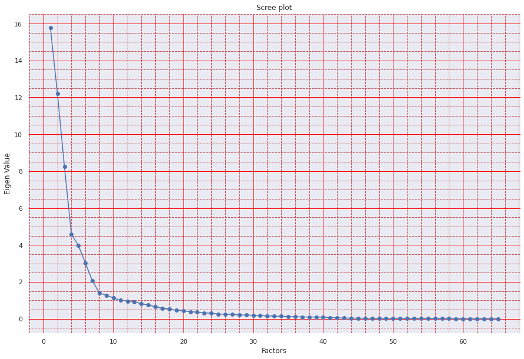

```python
sns.set()
plt.figure(figsize = (15,10))
plt.scatter(xvals, ev)
plt.plot(xvals, ev)
plt.title('Scree plot')
plt.xlabel('Factors')
plt.ylabel('Eigen Value')
plt.grid(color = 'red', )
plt.grid(b=True, which='minor', color='r', linestyle='--')
plt.minorticks_on()
plt.show()
```

```python
Factors  = pd.DataFrame.from_records(loadings)

Factors = Factors.add_prefix('Factor ')

Factors.index = fa_train_df.columns
Factors
```

|  | Factor 0 | Factor 1 | Factor 2 | Factor 3 | Factor 4 | Factor 5 | Factor 6 | Factor 7 | Factor 8 | Factor 9 | Factor 10 | Factor 11 | Factor 12 | Factor 13 | Factor 14 | Factor 15 | Factor 16 | Factor 17 | Factor 18 | Factor 19 | Factor 20 | Factor 21 | Factor 22 | Factor 23 | Factor 24 |
| --- | --- | --- | --- | --- | --- | --- | --- | --- | --- | --- | --- | --- | --- | --- | --- | --- | --- | --- | --- | --- | --- | --- | --- | --- | --- |
| AWater | -0.008030 | -0.020857 | -0.024649 | -0.019977 | 0.021628 | -0.016827 | 0.003462 | -0.023885 | 0.023228 | 0.006186 | 0.006970 | 0.009990 | 0.019131 | -0.000655 | -0.010665 | -0.010709 | -0.013515 | -0.000548 | 0.023525 | 0.012676 | -0.005391 | 0.024595 | -0.000844 | 0.009664 | 0.005839 |
| pop | 0.316628 | 0.928340 | -0.074583 | 0.042555 | 0.018686 | -0.113625 | 0.051978 | 0.007283 | 0.009517 | 0.010620 | -0.005281 | 0.001758 | -0.005029 | 0.007019 | -0.052264 | -0.085574 | 0.024815 | 0.007527 | 0.023059 | -0.006266 | -0.000684 | 0.003953 | 0.011193 | 0.014461 | -0.022708 |
| male_pop | 0.309499 | 0.907371 | -0.072707 | 0.023787 | 0.017516 | -0.136381 | 0.066263 | 0.004275 | 0.049887 | 0.023278 | -0.033451 | 0.015326 | -0.000980 | -0.002932 | -0.098455 | -0.094584 | 0.055410 | 0.016876 | 0.004437 | -0.060711 | 0.005366 | 0.111422 | 0.072541 | 0.039304 | -0.027681 |
| female_pop | 0.314401 | 0.921800 | -0.074230 | 0.059597 | 0.019269 | -0.088013 | 0.036456 | 0.009976 | -0.030052 | -0.002034 | 0.022261 | -0.011478 | -0.008785 | 0.016414 | -0.005617 | -0.073464 | -0.005701 | -0.001792 | 0.039977 | 0.046325 | -0.006452 | -0.098463 | -0.047655 | -0.009881 | -0.016447 |
| rent_mean | 0.751035 | -0.076934 | 0.341052 | 0.162947 | 0.087271 | -0.171451 | 0.029725 | 0.146160 | 0.187642 | -0.054281 | 0.121895 | -0.263252 | 0.192098 | 0.214779 | 0.018073 | 0.059190 | -0.031514 | 0.014712 | 0.030214 | -0.042247 | -0.105345 | -0.017381 | 0.023077 | 0.005187 | 0.011900 |
| rent_median | 0.710605 | -0.070852 | 0.333564 | 0.148596 | 0.068648 | -0.186519 | 0.032625 | 0.157785 | 0.193917 | -0.062856 | 0.121116 | -0.259652 | 0.182121 | 0.239431 | 0.055130 | 0.062025 | -0.012540 | 0.029471 | 0.063533 | -0.126473 | -0.111819 | -0.043674 | 0.018730 | -0.004939 | 0.018195 |
| rent_stdev | 0.575986 | -0.066959 | 0.264196 | 0.177531 | 0.216333 | -0.002339 | 0.089263 | -0.006037 | 0.024733 | 0.025985 | 0.093384 | -0.199482 | 0.145300 | 0.009644 | -0.252772 | 0.050476 | -0.140371 | -0.115705 | -0.124268 | 0.349939 | -0.005218 | 0.085138 | 0.013684 | 0.037652 | 0.005055 |
| rent_sample_weight | -0.408553 | 0.496742 | 0.240333 | -0.184624 | 0.288351 | 0.432710 | -0.044758 | -0.025267 | -0.155062 | 0.010972 | 0.015432 | 0.015355 | -0.005117 | -0.041470 | 0.040096 | 0.052627 | 0.100557 | -0.033579 | -0.034190 | 0.042757 | 0.033190 | -0.012757 | 0.044918 | -0.014302 | 0.109671 |
| rent_samples | -0.120414 | 0.577232 | 0.461817 | -0.174406 | 0.417334 | 0.448085 | -0.039422 | 0.027135 | -0.038649 | -0.009565 | 0.055358 | -0.090257 | 0.028003 | -0.022155 | 0.093553 | -0.002087 | 0.049235 | 0.002277 | -0.009896 | -0.005319 | -0.012327 | 0.021833 | -0.004315 | -0.012018 | -0.043624 |
| rent_gt_10 | -0.062089 | 0.118160 | 0.271098 | 0.281469 | -0.171955 | 0.034548 | -0.147577 | 0.252533 | 0.032000 | -0.258930 | -0.014009 | 0.113266 | 0.053286 | -0.010971 | 0.030599 | 0.004532 | 0.003664 | 0.157240 | -0.015392 | 0.002221 | -0.000428 | -0.008697 | -0.002955 | -0.014285 | -0.020026 |
| rent_gt_15 | -0.120837 | 0.139213 | 0.420405 | 0.499213 | -0.200897 | 0.048423 | -0.189358 | 0.357179 | 0.035303 | -0.432230 | -0.000108 | 0.218095 | 0.118326 | -0.080721 | -0.008526 | 0.001289 | 0.047102 | 0.197777 | -0.038271 | 0.100698 | 0.034742 | 0.022777 | 0.005568 | 0.016438 | 0.017205 |
| rent_gt_20 | -0.217510 | 0.119845 | 0.455763 | 0.595607 | -0.159687 | 0.042151 | -0.128464 | 0.165912 | 0.000465 | -0.205009 | 0.005468 | 0.116596 | 0.045664 | -0.068399 | -0.026546 | -0.001956 | 0.010355 | -0.158310 | 0.018949 | -0.014971 | -0.012036 | 0.001800 | 0.004354 | -0.002916 | 0.002185 |
| rent_gt_25 | -0.280615 | 0.108795 | 0.473080 | 0.682967 | -0.142981 | 0.020770 | -0.107931 | 0.026692 | -0.024039 | -0.051525 | 0.013263 | 0.058076 | 0.001753 | -0.065961 | -0.016161 | -0.005960 | 0.011170 | -0.330986 | 0.043721 | -0.070408 | -0.022687 | -0.003518 | -0.004452 | -0.008335 | -0.010044 |
| rent_gt_30 | -0.304362 | 0.096275 | 0.454719 | 0.702174 | -0.129143 | -0.013172 | -0.094187 | -0.102774 | -0.017843 | 0.099827 | 0.022774 | -0.011487 | -0.023592 | -0.031595 | 0.028345 | 0.001558 | 0.011809 | -0.144147 | 0.027254 | -0.052106 | -0.003962 | 0.009198 | -0.006585 | -0.004886 | -0.011524 |
| rent_gt_35 | -0.300839 | 0.080216 | 0.442412 | 0.708998 | -0.108671 | -0.039712 | -0.097454 | -0.190842 | -0.018123 | 0.197959 | 0.023150 | -0.059921 | -0.037345 | 0.004693 | 0.053101 | 0.003893 | 0.026468 | 0.030473 | 0.005043 | -0.017692 | 0.012915 | 0.014148 | -0.002783 | 0.001572 | -0.002469 |
| rent_gt_40 | -0.298054 | 0.069370 | 0.431747 | 0.697118 | -0.098097 | -0.048511 | -0.099841 | -0.252985 | -0.016867 | 0.262235 | 0.022338 | -0.087284 | -0.047410 | 0.033070 | 0.066481 | 0.001207 | 0.027813 | 0.190955 | -0.026155 | 0.035324 | 0.025168 | 0.016038 | 0.004397 | 0.004930 | 0.008453 |
| rent_gt_50 | -0.274327 | 0.044955 | 0.394089 | 0.600365 | -0.064714 | -0.043843 | -0.082648 | -0.239203 | -0.015006 | 0.224014 | 0.014474 | -0.077322 | -0.035271 | 0.043393 | 0.024564 | 0.000720 | 0.011419 | 0.173603 | -0.031685 | 0.051499 | 0.013440 | -0.004318 | -0.002591 | -0.001070 | -0.000723 |
| universe_samples | -0.139119 | 0.595498 | 0.432741 | -0.165293 | 0.425400 | 0.443765 | -0.029520 | 0.017156 | -0.035011 | -0.011439 | 0.052548 | -0.089158 | 0.035446 | -0.026869 | 0.092008 | 0.003392 | 0.041419 | 0.002573 | -0.007846 | -0.008156 | -0.006832 | 0.022845 | -0.003395 | -0.011784 | -0.042499 |
| used_samples | -0.112331 | 0.578800 | 0.457929 | -0.176024 | 0.415219 | 0.449480 | -0.037139 | 0.033743 | -0.041061 | -0.009620 | 0.058082 | -0.091950 | 0.026876 | -0.022445 | 0.095746 | -0.000650 | 0.049532 | 0.003234 | -0.007092 | -0.008276 | -0.013082 | 0.027528 | -0.004501 | -0.010395 | -0.048340 |
| hi_mean | 0.945900 | -0.149700 | 0.010288 | -0.002831 | 0.068753 | -0.163560 | -0.003523 | 0.010377 | -0.002689 | 0.020474 | 0.060006 | -0.016088 | 0.050982 | -0.052612 | 0.048460 | 0.033286 | 0.149027 | -0.017318 | 0.004828 | -0.013192 | 0.035732 | 0.018946 | 0.008500 | 0.006844 | 0.024905 |
| hi_median | 0.917835 | -0.135334 | -0.003391 | -0.031127 | 0.015172 | -0.205190 | -0.009655 | 0.041482 | 0.003882 | 0.013529 | 0.068067 | -0.045410 | 0.049231 | 0.041051 | 0.070815 | 0.025896 | 0.183882 | -0.029591 | 0.000121 | 0.002115 | 0.089725 | 0.040422 | 0.003365 | -0.024864 | 0.021864 |
| hi_stdev | 0.879252 | -0.167551 | 0.045238 | 0.079962 | 0.213512 | -0.028158 | 0.013969 | -0.098042 | -0.027547 | 0.054525 | 0.037027 | 0.057656 | 0.049225 | -0.273668 | -0.028537 | 0.058925 | 0.036057 | 0.024261 | 0.002861 | -0.026746 | -0.091617 | -0.041196 | 0.025759 | 0.083756 | 0.028851 |
| hi_sample_weight | -0.188260 | 0.876065 | -0.156204 | 0.065946 | 0.126492 | 0.318956 | -0.022748 | -0.000490 | -0.016941 | -0.012901 | -0.015237 | -0.011439 | -0.013274 | 0.013804 | 0.052507 | 0.158281 | -0.053280 | -0.010041 | -0.035932 | -0.010921 | 0.001350 | -0.003888 | 0.034211 | -0.030855 | 0.110848 |
| hi_samples | 0.325845 | 0.881477 | -0.169091 | 0.046602 | 0.125871 | 0.192328 | -0.046826 | 0.014610 | 0.010978 | 0.013585 | 0.015558 | -0.007066 | -0.010549 | 0.006563 | 0.012533 | 0.083435 | 0.031035 | 0.001771 | 0.000070 | 0.006609 | 0.004604 | 0.013286 | -0.114742 | 0.015642 | -0.064890 |
| family_mean | 0.937284 | -0.175699 | 0.002251 | 0.008574 | 0.134111 | -0.056212 | -0.061360 | -0.039672 | 0.005655 | 0.031262 | 0.042269 | 0.030029 | 0.056278 | -0.112818 | 0.006734 | 0.058133 | 0.171928 | -0.010603 | -0.025413 | 0.013201 | 0.020868 | -0.014559 | -0.013882 | -0.046713 | -0.001217 |
| family_median | 0.913175 | -0.173508 | -0.001517 | -0.000096 | 0.116102 | -0.086859 | -0.057753 | -0.029926 | -0.000168 | 0.026417 | 0.052982 | 0.008139 | 0.055184 | -0.031699 | 0.021299 | 0.067901 | 0.222757 | -0.031460 | -0.031007 | 0.039471 | 0.089176 | 0.011385 | -0.021986 | -0.087797 | 0.013238 |
| family_stdev | 0.810474 | -0.150398 | 0.060996 | 0.070632 | 0.233331 | 0.061218 | -0.037532 | -0.119289 | -0.008688 | 0.060458 | 0.020963 | 0.098590 | 0.054497 | -0.351363 | -0.058777 | 0.063532 | -0.020241 | 0.059856 | 0.005280 | -0.052349 | -0.168182 | -0.082781 | 0.026226 | 0.110902 | 0.009386 |
| family_sample_weight | -0.146798 | 0.880762 | -0.232279 | 0.100622 | -0.052172 | -0.020304 | 0.120845 | 0.044551 | -0.058435 | -0.038515 | -0.004896 | -0.038159 | -0.049745 | 0.022188 | 0.110030 | 0.052970 | -0.134978 | -0.003167 | 0.007000 | -0.043273 | -0.015634 | 0.049738 | 0.054495 | 0.044513 | 0.110213 |
| family_samples | 0.401737 | 0.835105 | -0.265319 | 0.091632 | -0.056203 | -0.097911 | 0.053724 | 0.042907 | -0.048977 | 0.000366 | 0.023757 | -0.004807 | -0.038969 | 0.015963 | 0.053785 | -0.026678 | -0.023918 | 0.000778 | 0.024194 | -0.011308 | 0.005819 | 0.042755 | -0.078298 | 0.083412 | -0.009584 |
| hc_mortgage_mean | 0.794767 | -0.137231 | 0.380132 | 0.124145 | 0.273473 | -0.035768 | 0.180132 | -0.016167 | -0.008630 | -0.059647 | -0.038641 | -0.011381 | -0.019299 | -0.037688 | -0.002787 | -0.028793 | -0.141815 | 0.011937 | 0.030393 | -0.075403 | 0.216760 | -0.008601 | -0.037922 | 0.017288 | 0.035618 |
| hc_mortgage_median | 0.775192 | -0.134997 | 0.388573 | 0.117201 | 0.266183 | -0.051068 | 0.173213 | -0.009222 | -0.014377 | -0.057241 | -0.028381 | -0.021224 | -0.018259 | 0.005066 | 0.000735 | -0.012997 | -0.096789 | -0.006678 | 0.016929 | -0.057800 | 0.219995 | -0.017672 | -0.025446 | 0.045212 | 0.045944 |
| hc_mortgage_stdev | 0.688716 | -0.143684 | 0.170369 | 0.151884 | 0.248742 | 0.063605 | 0.178396 | -0.063050 | 0.003328 | -0.031287 | -0.053229 | 0.012396 | 0.022591 | -0.194720 | -0.031149 | -0.035556 | -0.196613 | 0.065609 | 0.064824 | -0.073607 | 0.018298 | 0.043986 | -0.032167 | -0.092990 | -0.011721 |
| hc_mortgage_sample_weight | 0.123275 | 0.647476 | -0.513995 | 0.025030 | -0.320955 | -0.045548 | -0.153602 | 0.084557 | -0.011050 | 0.089013 | 0.011937 | 0.012713 | -0.088219 | 0.010328 | -0.037273 | 0.164664 | -0.010500 | 0.003115 | -0.006930 | 0.017357 | -0.057234 | 0.026038 | -0.057295 | -0.022156 | 0.086767 |
| hc_mortgage_samples | 0.598235 | 0.608231 | -0.291032 | 0.072066 | -0.256366 | -0.124170 | -0.096097 | 0.107006 | -0.010745 | 0.078377 | 0.011752 | 0.017898 | -0.106232 | 0.014538 | -0.091868 | 0.014201 | 0.037648 | 0.006598 | 0.039486 | 0.022074 | -0.013407 | 0.013756 | -0.183941 | 0.042137 | 0.000912 |
| hc_mean | 0.706710 | -0.168336 | 0.292318 | 0.121974 | 0.341527 | -0.010591 | 0.090930 | -0.070589 | -0.118882 | -0.098457 | -0.038490 | 0.232689 | -0.313693 | 0.236372 | 0.003859 | 0.059318 | 0.011781 | -0.005573 | -0.019645 | 0.024229 | -0.072565 | 0.001051 | 0.028401 | 0.001883 | -0.014076 |
| hc_median | 0.676720 | -0.158593 | 0.293293 | 0.111876 | 0.327699 | -0.016717 | 0.081307 | -0.064661 | -0.117819 | -0.099079 | -0.034879 | 0.220754 | -0.308268 | 0.263566 | 0.019834 | 0.064359 | 0.038566 | -0.022212 | -0.048678 | 0.025773 | -0.021821 | -0.048891 | 0.056386 | 0.088581 | -0.017112 |
| hc_stdev | 0.542035 | -0.133332 | 0.136848 | 0.157495 | 0.360459 | 0.022305 | 0.138128 | -0.104685 | -0.035423 | -0.061892 | 0.001232 | 0.140391 | -0.123553 | -0.007467 | -0.066555 | 0.006840 | -0.086350 | 0.045587 | 0.096532 | 0.003413 | -0.149747 | 0.126022 | -0.061004 | -0.180683 | 0.012102 |
| hc_samples | 0.107384 | 0.409775 | -0.740142 | 0.301324 | 0.081438 | 0.000244 | 0.092606 | -0.185053 | 0.114176 | -0.084332 | -0.069487 | 0.104454 | 0.101894 | 0.039598 | 0.043045 | 0.205841 | -0.052149 | -0.011434 | -0.058039 | -0.007527 | 0.048677 | -0.026414 | 0.024862 | -0.014173 | -0.101103 |
| hc_sample_weight | -0.103574 | 0.408160 | -0.756799 | 0.245713 | 0.014813 | -0.011822 | 0.084315 | -0.169457 | 0.135981 | -0.062551 | -0.059420 | 0.052203 | 0.159477 | -0.018800 | 0.056458 | 0.235490 | -0.077249 | -0.009755 | -0.048708 | -0.028931 | 0.073486 | -0.015176 | 0.052125 | -0.025284 | -0.057207 |
| home_equity_second_mortgage | 0.198156 | 0.103417 | 0.315636 | -0.171069 | -0.585994 | 0.300925 | 0.324288 | -0.209008 | 0.198486 | -0.109102 | 0.228233 | 0.028257 | -0.064793 | -0.010151 | 0.014639 | -0.006411 | 0.018804 | -0.002098 | -0.010393 | 0.012471 | -0.003644 | -0.001136 | -0.016121 | 0.016260 | -0.005802 |
| second_mortgage | 0.220514 | 0.096163 | 0.341427 | -0.161656 | -0.601042 | 0.308784 | 0.353486 | -0.228378 | 0.226336 | -0.127274 | 0.268075 | 0.025806 | -0.087932 | -0.026702 | 0.010499 | -0.013464 | 0.011000 | -0.005108 | -0.016634 | 0.009353 | 0.018257 | -0.020497 | -0.012723 | 0.013182 | 0.000136 |
| home_equity | 0.624583 | -0.022796 | 0.301569 | -0.070737 | -0.444061 | 0.294502 | 0.138990 | -0.031060 | -0.163626 | 0.068987 | -0.362187 | 0.026741 | 0.186037 | 0.077943 | 0.026615 | 0.003025 | 0.014510 | -0.008812 | 0.012307 | 0.012735 | -0.025588 | 0.008402 | -0.016264 | 0.017987 | -0.002601 |
| debt | 0.518738 | 0.179453 | 0.458924 | -0.213163 | -0.371055 | -0.024004 | -0.185291 | 0.321368 | -0.102781 | 0.156275 | 0.019940 | -0.123910 | -0.243388 | -0.104856 | -0.035132 | 0.124832 | -0.096310 | 0.015096 | -0.038402 | -0.025982 | 0.034714 | -0.023517 | 0.084349 | -0.050777 | -0.050623 |
| second_mortgage_cdf | -0.330729 | -0.100344 | -0.151006 | 0.103402 | 0.583918 | -0.249547 | -0.227157 | 0.144156 | -0.101671 | 0.070903 | -0.217742 | -0.018763 | 0.079280 | 0.035027 | 0.019434 | -0.013083 | -0.009053 | -0.010771 | 0.002280 | 0.008351 | 0.009726 | -0.017757 | -0.041191 | 0.038337 | -0.010763 |
| home_equity_cdf | -0.646926 | 0.013064 | -0.260679 | 0.057882 | 0.455030 | -0.299996 | -0.105372 | 0.018169 | 0.169290 | -0.067565 | 0.298644 | -0.027054 | -0.138146 | -0.060558 | -0.006920 | -0.011575 | -0.001937 | -0.006369 | -0.010573 | -0.000948 | 0.039713 | -0.009293 | -0.012461 | 0.018397 | 0.001958 |
| debt_cdf | -0.507963 | -0.176077 | -0.480322 | 0.215019 | 0.362428 | 0.055849 | 0.166660 | -0.314874 | 0.072337 | -0.150817 | -0.005213 | 0.129803 | 0.225101 | 0.093270 | 0.031510 | -0.096993 | 0.070435 | -0.002724 | 0.036849 | 0.014506 | -0.039920 | 0.030801 | -0.039761 | 0.022368 | 0.051148 |
| hs_degree | 0.675928 | -0.131399 | -0.212700 | -0.070690 | -0.051584 | 0.327715 | -0.523473 | -0.059239 | 0.070534 | 0.110070 | 0.145865 | 0.172658 | 0.087652 | 0.104756 | 0.011531 | -0.080751 | -0.108209 | -0.014199 | 0.005521 | -0.013298 | 0.029513 | 0.009355 | 0.015678 | 0.007514 | 0.003535 |
| hs_degree_male | 0.665115 | -0.119091 | -0.177849 | -0.068568 | -0.034502 | 0.310114 | -0.481345 | -0.049027 | 0.052547 | 0.091693 | 0.131571 | 0.133361 | 0.076992 | 0.083455 | 0.009015 | -0.073902 | -0.086273 | -0.011820 | -0.012416 | -0.006574 | 0.022679 | -0.012115 | 0.003352 | 0.017555 | -0.003304 |
| hs_degree_female | 0.637108 | -0.133816 | -0.232360 | -0.067365 | -0.061792 | 0.302680 | -0.480660 | -0.056300 | 0.080308 | 0.106318 | 0.117679 | 0.170133 | 0.074383 | 0.088127 | 0.001026 | -0.052870 | -0.073042 | -0.008353 | 0.020535 | -0.016636 | 0.018019 | 0.032144 | 0.024265 | -0.007256 | 0.004749 |
| male_age_mean | 0.238140 | -0.329571 | -0.557797 | 0.375286 | 0.125262 | 0.422160 | 0.103729 | 0.134568 | 0.184282 | 0.032278 | -0.096077 | -0.094625 | -0.107991 | -0.031343 | 0.023362 | -0.030750 | 0.017712 | 0.003567 | 0.122922 | 0.086538 | 0.002731 | -0.047120 | 0.042293 | -0.010011 | -0.023085 |
| male_age_median | 0.312906 | -0.322783 | -0.573598 | 0.360488 | 0.065287 | 0.350204 | 0.121286 | 0.164955 | 0.184740 | 0.049786 | -0.106277 | -0.098348 | -0.149686 | -0.043019 | 0.088724 | -0.049546 | 0.041010 | -0.003689 | 0.226127 | 0.127317 | 0.028958 | -0.008861 | 0.069705 | 0.027867 | -0.004097 |
| male_age_stdev | 0.048698 | -0.135400 | -0.507846 | 0.285904 | -0.086170 | 0.119510 | 0.185825 | 0.042735 | -0.520718 | -0.039059 | 0.284537 | -0.043167 | 0.087539 | 0.048994 | -0.029967 | -0.027048 | -0.027101 | 0.028442 | 0.061102 | -0.023240 | 0.013282 | -0.033410 | 0.005531 | -0.007739 | 0.003928 |
| male_age_sample_weight | 0.258537 | 0.881465 | -0.017738 | 0.014238 | 0.026206 | -0.160011 | 0.009773 | -0.075621 | 0.097692 | 0.014224 | -0.086328 | 0.042462 | 0.027142 | -0.003897 | -0.129760 | -0.149992 | 0.041059 | 0.006449 | -0.043908 | -0.035663 | 0.005142 | 0.023043 | 0.132160 | -0.037905 | 0.018675 |
| male_age_samples | 0.309499 | 0.907371 | -0.072707 | 0.023787 | 0.017516 | -0.136381 | 0.066263 | 0.004275 | 0.049887 | 0.023278 | -0.033451 | 0.015326 | -0.000980 | -0.002932 | -0.098455 | -0.094584 | 0.055410 | 0.016876 | 0.004437 | -0.060711 | 0.005366 | 0.111422 | 0.072541 | 0.039304 | -0.027681 |
| female_age_mean | 0.176202 | -0.312904 | -0.539027 | 0.409527 | 0.115989 | 0.482207 | 0.108938 | 0.155780 | 0.095155 | 0.013678 | -0.051636 | -0.120290 | -0.081711 | 0.018959 | -0.114044 | -0.083332 | 0.030064 | 0.007314 | -0.241768 | -0.102891 | -0.029380 | -0.038164 | -0.046755 | -0.023080 | 0.007528 |
| female_age_median | 0.249542 | -0.311946 | -0.575716 | 0.398955 | 0.041040 | 0.382293 | 0.123586 | 0.164118 | 0.088042 | 0.022843 | -0.059545 | -0.108450 | -0.107242 | 0.012180 | -0.063437 | -0.096003 | 0.039766 | 0.002096 | -0.172203 | -0.093975 | -0.008435 | 0.016085 | -0.030513 | 0.007701 | 0.030752 |
| female_age_stdev | -0.058587 | -0.099132 | -0.425121 | 0.221687 | -0.046783 | 0.152071 | 0.198997 | 0.051484 | -0.527279 | -0.000304 | 0.269699 | -0.012148 | 0.124806 | 0.049008 | -0.162311 | -0.003919 | 0.027935 | 0.036827 | 0.025282 | -0.033045 | 0.019980 | -0.019385 | 0.055325 | -0.007339 | -0.043722 |
| female_age_sample_weight | 0.258190 | 0.895682 | -0.007466 | 0.039612 | 0.035136 | -0.115881 | -0.025042 | -0.077702 | 0.032502 | -0.008839 | -0.036285 | 0.024359 | 0.019198 | 0.011682 | -0.025007 | -0.135049 | -0.019462 | -0.012031 | 0.025585 | 0.094182 | -0.004899 | -0.208256 | 0.033208 | -0.104382 | 0.037067 |
| female_age_samples | 0.314401 | 0.921800 | -0.074230 | 0.059597 | 0.019269 | -0.088013 | 0.036456 | 0.009976 | -0.030052 | -0.002034 | 0.022261 | -0.011478 | -0.008785 | 0.016414 | -0.005617 | -0.073464 | -0.005701 | -0.001792 | 0.039977 | 0.046325 | -0.006452 | -0.098463 | -0.047655 | -0.009881 | -0.016447 |
| pct_own | 0.471130 | -0.146936 | -0.642621 | 0.194182 | -0.329529 | -0.238129 | -0.031339 | -0.000509 | -0.018127 | 0.019735 | -0.004225 | 0.048182 | -0.045417 | -0.023311 | 0.013242 | 0.009482 | 0.069716 | -0.010924 | -0.020659 | -0.000092 | -0.002225 | 0.021866 | 0.052445 | -0.059480 | 0.016266 |
| married | 0.545870 | -0.052070 | -0.506344 | 0.118558 | -0.139471 | -0.141766 | 0.115353 | 0.146835 | -0.147828 | 0.023290 | 0.117736 | -0.007609 | -0.018502 | -0.095057 | 0.437972 | -0.104851 | -0.068232 | -0.042933 | -0.044285 | 0.084168 | -0.051421 | 0.082753 | 0.016978 | 0.013824 | -0.009433 |
| married_snp | -0.360438 | 0.064842 | 0.295742 | 0.030681 | 0.167844 | -0.044964 | 0.481720 | 0.371547 | 0.175165 | 0.427447 | 0.117284 | 0.351398 | 0.139810 | 0.024906 | 0.005220 | -0.001035 | -0.006607 | 0.003664 | -0.030128 | 0.001230 | 0.001280 | -0.002320 | 0.034228 | -0.010709 | -0.011374 |
| separated | -0.361358 | 0.032732 | 0.162859 | 0.026486 | 0.076454 | 0.025407 | 0.278131 | 0.255983 | 0.098369 | 0.291050 | 0.091734 | 0.265463 | 0.093676 | 0.050715 | 0.004045 | 0.054993 | 0.003129 | -0.005038 | 0.016149 | 0.011524 | 0.014471 | -0.026125 | -0.060060 | -0.004176 | 0.026243 |
| divorced | -0.398625 | -0.032687 | -0.182270 | -0.000142 | -0.032195 | 0.325393 | -0.082366 | 0.050969 | 0.065166 | 0.034327 | 0.029367 | -0.023026 | -0.038292 | 0.046337 | -0.215058 | 0.134312 | 0.085960 | 0.041298 | 0.236141 | -0.036942 | 0.045726 | 0.049997 | 0.014444 | 0.036631 | 0.016335 |
| Bad_Debt | 0.622173 | -0.021272 | 0.314708 | -0.069481 | -0.452484 | 0.294705 | 0.152387 | -0.039505 | -0.142378 | 0.057632 | -0.325805 | 0.023707 | 0.165448 | 0.065590 | 0.022075 | 0.000146 | 0.008319 | -0.009076 | 0.009408 | 0.008543 | -0.012608 | -0.000800 | -0.008577 | 0.009234 | 0.002399 |

```python
fa = FactorAnalyzer( rotation="varimax", n_factors = 12)
fa.fit(fa_train_df)
loadings = fa.loadings_
```

```python
Factors  = pd.DataFrame.from_records(loadings)

Factors = Factors.add_prefix('Factor ')

Factors.index = fa_train_df.columns
Factors
```

|  | Factor 0 | Factor 1 | Factor 2 | Factor 3 | Factor 4 | Factor 5 | Factor 6 | Factor 7 | Factor 8 | Factor 9 | Factor 10 | Factor 11 |
| --- | --- | --- | --- | --- | --- | --- | --- | --- | --- | --- | --- | --- |
| AWater | -0.002565 | -0.015722 | -0.011449 | -0.019316 | -0.004018 | 0.004434 | -0.008651 | -0.019383 | -0.036533 | -0.029425 | -0.012425 | 0.008398 |
| pop | 0.118773 | 0.973057 | 0.110002 | -0.010393 | -0.103933 | -0.012189 | 0.037789 | 0.018302 | 0.040970 | 0.019183 | -0.021705 | 0.021125 |
| male_pop | 0.116161 | 0.951993 | 0.088453 | -0.023498 | -0.105697 | -0.031971 | 0.037243 | 0.023961 | 0.030771 | 0.005137 | -0.067479 | 0.021135 |
| female_pop | 0.117133 | 0.960596 | 0.128834 | 0.002650 | -0.098851 | 0.009770 | 0.037494 | 0.012379 | 0.049662 | 0.032972 | 0.024995 | 0.020498 |
| rent_mean | 0.807012 | 0.062148 | -0.087967 | 0.040331 | -0.020796 | 0.067642 | 0.089073 | 0.033717 | 0.136721 | 0.139662 | -0.104416 | 0.439374 |
| rent_median | 0.759941 | 0.060896 | -0.098825 | 0.032431 | -0.034521 | 0.051893 | 0.090290 | 0.028684 | 0.141189 | 0.142860 | -0.108429 | 0.411006 |
| rent_stdev | 0.664295 | 0.028363 | 0.063908 | 0.088021 | 0.048559 | 0.046419 | 0.034425 | 0.051240 | 0.045906 | 0.002284 | 0.007704 | 0.171378 |
| rent_sample_weight | -0.319561 | 0.207160 | 0.780071 | 0.041763 | -0.118922 | -0.086099 | -0.035731 | 0.004692 | -0.010851 | 0.004285 | 0.029338 | -0.128758 |
| rent_samples | 0.016911 | 0.293161 | 0.925304 | 0.049678 | -0.137682 | -0.075879 | 0.012975 | -0.004958 | 0.058412 | 0.051152 | -0.086460 | 0.024491 |
| rent_gt_10 | -0.030254 | 0.046841 | 0.034082 | 0.204436 | -0.042080 | -0.003049 | 0.039419 | 0.034210 | 0.086339 | 0.566441 | -0.046109 | 0.025785 |
| rent_gt_15 | -0.012814 | 0.032287 | 0.063602 | 0.370382 | -0.049854 | -0.043407 | 0.040852 | 0.023681 | 0.062662 | 0.796872 | -0.033453 | 0.017078 |
| rent_gt_20 | -0.039091 | -0.001216 | 0.086327 | 0.581573 | -0.037933 | -0.106734 | 0.029509 | 0.011289 | 0.037461 | 0.637403 | -0.011776 | -0.012349 |
| rent_gt_25 | -0.060123 | -0.015518 | 0.084115 | 0.743099 | -0.036407 | -0.137767 | 0.016910 | 0.001414 | 0.025704 | 0.446934 | 0.000765 | -0.021991 |
| rent_gt_30 | -0.071142 | -0.018194 | 0.061268 | 0.863869 | -0.038482 | -0.135940 | 0.009822 | -0.011113 | 0.015248 | 0.268184 | -0.003847 | -0.005768 |
| rent_gt_35 | -0.060589 | -0.023250 | 0.045948 | 0.937023 | -0.044473 | -0.119997 | -0.006933 | -0.014587 | 0.009793 | 0.126800 | -0.010681 | 0.010746 |
| rent_gt_40 | -0.059020 | -0.029879 | 0.043080 | 0.941098 | -0.051324 | -0.108259 | -0.010293 | -0.012757 | 0.000971 | 0.049884 | -0.018837 | 0.013925 |
| rent_gt_50 | -0.046934 | -0.049122 | 0.052577 | 0.830890 | -0.059772 | -0.102346 | -0.015427 | -0.012446 | -0.017275 | 0.030421 | -0.022380 | 0.007752 |
| universe_samples | -0.003391 | 0.314180 | 0.920668 | 0.049827 | -0.127234 | -0.084885 | 0.003536 | -0.012164 | 0.032434 | 0.043335 | -0.080222 | 0.024398 |
| used_samples | 0.021026 | 0.297265 | 0.922415 | 0.043629 | -0.133711 | -0.075287 | 0.014941 | -0.004178 | 0.064483 | 0.052117 | -0.082227 | 0.026248 |
| hi_mean | 0.842228 | 0.107508 | -0.264595 | -0.192618 | 0.036977 | 0.287462 | 0.052451 | 0.087279 | 0.126573 | -0.076356 | 0.019531 | 0.117230 |
| hi_median | 0.790312 | 0.120040 | -0.304240 | -0.213338 | 0.007526 | 0.274413 | 0.060978 | 0.084746 | 0.154852 | -0.065789 | 0.016279 | 0.152398 |
| hi_stdev | 0.850217 | 0.056013 | -0.111995 | -0.092372 | 0.111405 | 0.280510 | 0.018652 | 0.081470 | 0.026521 | -0.113481 | 0.028734 | -0.001502 |
| hi_sample_weight | -0.333117 | 0.757549 | 0.476871 | 0.058210 | 0.118458 | -0.004383 | -0.015829 | -0.014888 | -0.079090 | 0.050636 | 0.044142 | -0.059336 |
| hi_samples | 0.086797 | 0.906702 | 0.310292 | -0.052424 | 0.115287 | 0.159455 | 0.022564 | 0.017435 | 0.020682 | 0.009213 | 0.018349 | -0.003712 |
| family_mean | 0.837914 | 0.067591 | -0.178777 | -0.174542 | 0.092656 | 0.365836 | 0.031284 | 0.091465 | 0.081023 | -0.088740 | 0.000804 | 0.060394 |
| family_median | 0.811937 | 0.067412 | -0.198630 | -0.177316 | 0.070486 | 0.347454 | 0.029321 | 0.083565 | 0.088433 | -0.087939 | 0.009859 | 0.080133 |
| family_stdev | 0.775198 | 0.037774 | -0.027921 | -0.075573 | 0.129336 | 0.312500 | 0.017764 | 0.085063 | 0.013502 | -0.095324 | -0.003060 | -0.032201 |
| family_sample_weight | -0.313933 | 0.846888 | 0.128726 | 0.038131 | 0.002316 | -0.167852 | 0.005478 | -0.031839 | -0.037001 | 0.053514 | 0.106589 | -0.024816 |
| family_samples | 0.122671 | 0.957433 | -0.040712 | -0.070662 | 0.031809 | 0.067104 | 0.040325 | 0.021327 | 0.061766 | 0.009065 | 0.099412 | 0.006188 |
| hc_mortgage_mean | 0.942833 | -0.005060 | 0.047615 | 0.005201 | 0.011912 | -0.000937 | 0.069203 | 0.121326 | 0.058256 | 0.034527 | -0.052766 | -0.008548 |
| hc_mortgage_median | 0.926760 | -0.009355 | 0.045969 | 0.009155 | -0.008430 | -0.007787 | 0.064879 | 0.114363 | 0.067729 | 0.036250 | -0.049237 | 0.003582 |
| hc_mortgage_stdev | 0.770293 | 0.005758 | 0.021886 | -0.015376 | 0.155352 | 0.053039 | 0.055483 | 0.122274 | -0.035177 | -0.022211 | -0.000407 | -0.025718 |
| hc_mortgage_sample_weight | -0.310360 | 0.764995 | -0.228647 | -0.099720 | 0.131647 | 0.236925 | 0.029556 | 0.007569 | 0.150248 | -0.024170 | 0.082449 | -0.013857 |
| hc_mortgage_samples | 0.203385 | 0.806930 | -0.264489 | -0.098958 | 0.083378 | 0.266716 | 0.094862 | 0.078163 | 0.254481 | 0.013497 | 0.037747 | 0.002432 |
| hc_mean | 0.864815 | -0.038791 | 0.045892 | -0.008114 | 0.023709 | 0.071566 | 0.000069 | 0.008799 | 0.065098 | 0.040821 | -0.017112 | -0.375715 |
| hc_median | 0.824647 | -0.038142 | 0.048103 | -0.006252 | 0.009134 | 0.070290 | -0.001431 | 0.011425 | 0.067445 | 0.041210 | -0.018920 | -0.331359 |
| hc_stdev | 0.689321 | -0.011368 | 0.056574 | 0.002086 | 0.115542 | 0.031306 | -0.024424 | -0.028344 | -0.079949 | -0.023325 | 0.016711 | -0.201539 |
| hc_samples | -0.112018 | 0.615049 | -0.236847 | -0.063386 | 0.412475 | 0.128526 | -0.115826 | -0.071959 | -0.459988 | -0.078053 | 0.135367 | -0.049882 |
| hc_sample_weight | -0.322851 | 0.560848 | -0.228109 | -0.057834 | 0.367140 | 0.071984 | -0.117177 | -0.085548 | -0.460375 | -0.091846 | 0.127276 | 0.023233 |
| home_equity_second_mortgage | 0.040150 | 0.038393 | 0.041731 | 0.008310 | -0.087640 | -0.001043 | 0.906488 | 0.165242 | 0.072752 | 0.037005 | -0.055997 | 0.012006 |
| second_mortgage | 0.071579 | 0.032373 | 0.040034 | 0.020256 | -0.084421 | -0.010218 | 0.968052 | 0.136768 | 0.070826 | 0.041188 | -0.060230 | 0.009212 |
| home_equity | 0.392812 | 0.037166 | -0.026245 | -0.027034 | -0.000749 | 0.174029 | 0.365422 | 0.795048 | 0.183134 | 0.055445 | -0.012747 | 0.013665 |
| debt | 0.317751 | 0.170269 | 0.004369 | -0.034264 | -0.242078 | 0.151563 | 0.246358 | 0.213210 | 0.750097 | 0.113839 | -0.127975 | 0.042594 |
| second_mortgage_cdf | -0.093418 | -0.117295 | 0.084158 | 0.020376 | 0.007883 | -0.118427 | -0.773911 | -0.170782 | -0.143510 | -0.029220 | -0.041107 | -0.003243 |
| home_equity_cdf | -0.391220 | -0.060247 | 0.044360 | 0.030691 | -0.024445 | -0.219575 | -0.379681 | -0.731632 | -0.222625 | -0.057715 | -0.018463 | 0.003395 |
| debt_cdf | -0.324287 | -0.164970 | 0.005233 | 0.029430 | 0.259547 | -0.117826 | -0.242137 | -0.210345 | -0.750485 | -0.112845 | 0.159488 | -0.061318 |
| hs_degree | 0.339804 | 0.022270 | -0.018775 | -0.163907 | 0.224067 | 0.859045 | 0.067533 | 0.052101 | 0.121053 | -0.033009 | -0.020519 | 0.021324 |
| hs_degree_male | 0.356170 | 0.026231 | -0.002941 | -0.158892 | 0.206734 | 0.797452 | 0.063368 | 0.059668 | 0.126038 | -0.029049 | -0.014276 | 0.028819 |
| hs_degree_female | 0.309404 | 0.023041 | -0.048963 | -0.168807 | 0.233170 | 0.798824 | 0.064383 | 0.057149 | 0.106723 | -0.040725 | -0.028223 | 0.009985 |
| male_age_mean | 0.125872 | -0.107762 | -0.136306 | -0.064252 | 0.906543 | 0.129006 | -0.058532 | -0.003930 | -0.102923 | -0.043205 | 0.085262 | -0.005867 |
| male_age_median | 0.166434 | -0.067991 | -0.229739 | -0.091847 | 0.862753 | 0.127948 | -0.040185 | 0.009562 | -0.050380 | -0.053332 | 0.088407 | -0.007098 |
| male_age_stdev | -0.041527 | 0.008704 | -0.207215 | -0.022285 | 0.290835 | 0.061035 | -0.029511 | -0.014497 | -0.068551 | -0.027444 | 0.860615 | -0.000835 |
| male_age_sample_weight | 0.090876 | 0.900952 | 0.097956 | 0.021914 | -0.170381 | -0.001338 | 0.020587 | 0.036816 | -0.033040 | 0.004436 | -0.150297 | 0.005987 |
| male_age_samples | 0.116161 | 0.951993 | 0.088453 | -0.023498 | -0.105697 | -0.031971 | 0.037243 | 0.023961 | 0.030771 | 0.005137 | -0.067479 | 0.021135 |
| female_age_mean | 0.077659 | -0.120081 | -0.079005 | -0.028162 | 0.873170 | 0.124964 | -0.055367 | 0.004760 | -0.100722 | -0.004180 | 0.193929 | 0.001160 |
| female_age_median | 0.110758 | -0.077506 | -0.202710 | -0.054994 | 0.859018 | 0.123083 | -0.038423 | 0.017822 | -0.058938 | -0.016732 | 0.193804 | -0.001554 |
| female_age_stdev | -0.113371 | -0.011774 | -0.104369 | -0.020123 | 0.247652 | -0.000111 | -0.045455 | 0.006930 | -0.072728 | -0.039332 | 0.703473 | -0.022676 |
| female_age_sample_weight | 0.091266 | 0.901136 | 0.144896 | 0.047054 | -0.172952 | 0.039656 | 0.020455 | 0.022846 | -0.018941 | 0.028513 | -0.079528 | 0.002198 |
| female_age_samples | 0.117133 | 0.960596 | 0.128834 | 0.002650 | -0.098851 | 0.009770 | 0.037494 | 0.012379 | 0.049662 | 0.032972 | 0.024995 | 0.020498 |
| pct_own | 0.137198 | 0.199972 | -0.746074 | -0.149073 | 0.310310 | 0.305570 | 0.005489 | 0.034506 | -0.001294 | -0.077763 | 0.187672 | -0.012914 |
| married | 0.294447 | 0.236247 | -0.462397 | -0.233852 | 0.288171 | 0.170328 | 0.003928 | 0.022494 | 0.067469 | -0.072837 | 0.284522 | 0.049219 |
| married_snp | -0.095049 | -0.070985 | 0.213294 | 0.108581 | -0.025830 | -0.549378 | 0.001783 | -0.081425 | 0.072712 | 0.016851 | -0.075007 | 0.029013 |
| separated | -0.187318 | -0.084045 | 0.168269 | 0.089542 | 0.022699 | -0.397799 | -0.001444 | -0.071074 | 0.070005 | 0.021456 | -0.032313 | 0.006917 |
| divorced | -0.440976 | -0.122957 | 0.171028 | 0.011599 | 0.237738 | 0.035058 | 0.004507 | -0.064212 | -0.024038 | 0.003156 | 0.029838 | -0.021249 |
| Bad_Debt | 0.397019 | 0.035405 | -0.024785 | -0.020329 | -0.003430 | 0.165339 | 0.403523 | 0.760488 | 0.185990 | 0.057881 | -0.016114 | 0.012949 |

```python
#  • Highschool graduation rates
#                         • Median population age
#                         • Second mortgage statistics
#                         • Percent own
#                         • Bad debt expense

Factors_df = round(Factors.loc[['hs_degree', 'hs_degree_male', 'hs_degree_female',"male_age_median", "female_age_median", "home_equity_second_mortgage", 'second_mortgage', 'second_mortgage_cdf', 'pct_own', 'Bad_Debt'], :], 2)
```

```python
def color_negative_red(value):
  """
  Colors elements in a dateframe
  green if positive and red if
  negative. Does not color NaN
  values.
  """

  if value < -0.6:
    color = 'red'
  elif value > 0.6:
    color = 'green'
  else:
    color = 'black'

  return 'color: %s' % color
```

```python
Factors_df.style.applymap(color_negative_red)
```

|  | Factor 0 | Factor 1 | Factor 2 | Factor 3 | Factor 4 | Factor 5 | Factor 6 | Factor 7 | Factor 8 | Factor 9 | Factor 10 | Factor 11 |
| --- | --- | --- | --- | --- | --- | --- | --- | --- | --- | --- | --- | --- |
| hs_degree | 0.34 | 0.02 | -0.02 | -0.16 | 0.22 | 0.86 | 0.07 | 0.05 | 0.12 | -0.03 | -0.02 | 0.02 |
| hs_degree_male | 0.36 | 0.03 | -0 | -0.16 | 0.21 | 0.8 | 0.06 | 0.06 | 0.13 | -0.03 | -0.01 | 0.03 |
| hs_degree_female | 0.31 | 0.02 | -0.05 | -0.17 | 0.23 | 0.8 | 0.06 | 0.06 | 0.11 | -0.04 | -0.03 | 0.01 |
| male_age_median | 0.17 | -0.07 | -0.23 | -0.09 | 0.86 | 0.13 | -0.04 | 0.01 | -0.05 | -0.05 | 0.09 | -0.01 |
| female_age_median | 0.11 | -0.08 | -0.2 | -0.05 | 0.86 | 0.12 | -0.04 | 0.02 | -0.06 | -0.02 | 0.19 | -0 |
| home_equity_second_mortgage | 0.04 | 0.04 | 0.04 | 0.01 | -0.09 | -0 | 0.91 | 0.17 | 0.07 | 0.04 | -0.06 | 0.01 |
| second_mortgage | 0.07 | 0.03 | 0.04 | 0.02 | -0.08 | -0.01 | 0.97 | 0.14 | 0.07 | 0.04 | -0.06 | 0.01 |
| second_mortgage_cdf | -0.09 | -0.12 | 0.08 | 0.02 | 0.01 | -0.12 | -0.77 | -0.17 | -0.14 | -0.03 | -0.04 | -0 |
| pct_own | 0.14 | 0.2 | -0.75 | -0.15 | 0.31 | 0.31 | 0.01 | 0.03 | -0 | -0.08 | 0.19 | -0.01 |
| Bad_Debt | 0.4 | 0.04 | -0.02 | -0.02 | -0 | 0.17 | 0.4 | 0.76 | 0.19 | 0.06 | -0.02 | 0.01 |

# Looks like "Related parameters" are loading on Unique Factors.

```python
len(fa_train_df.columns)
```

```
65
```

```python
# Get variance of each factors
fact_variance  = fa.get_factor_variance()
fact_variance
```

```
(array([12.07377811, 11.80320354,  5.20124477,  4.6917126 ,  4.3777047 ,
         3.7566409 ,  3.03577142,  2.05814893,  2.04569779,  1.84265301,
         1.66448054,  0.77400976]),
 array([0.18575043, 0.18158775, 0.08001915, 0.07218019, 0.0673493 ,
        0.05779448, 0.04670418, 0.03166383, 0.03147227, 0.02834851,
        0.02560739, 0.01190784]),
 array([0.18575043, 0.36733818, 0.44735733, 0.51953752, 0.58688683,
        0.6446813 , 0.69138548, 0.72304931, 0.75452158, 0.78287009,
        0.80847748, 0.82038532]))
```

```python
Factor_variance  = pd.DataFrame.from_records(fact_variance)

Factor_variance = Factor_variance.add_prefix('Factor ')

Factor_variance.index = ['SS Loadings', 'Proportion Var', 'Cumulative Var']
round(Factor_variance, 2)
```

|  | Factor 0 | Factor 1 | Factor 2 | Factor 3 | Factor 4 | Factor 5 | Factor 6 | Factor 7 | Factor 8 | Factor 9 | Factor 10 | Factor 11 |
| --- | --- | --- | --- | --- | --- | --- | --- | --- | --- | --- | --- | --- |
| SS Loadings | 12.07 | 11.80 | 5.20 | 4.69 | 4.38 | 3.76 | 3.04 | 2.06 | 2.05 | 1.84 | 1.66 | 0.77 |
| Proportion Var | 0.19 | 0.18 | 0.08 | 0.07 | 0.07 | 0.06 | 0.05 | 0.03 | 0.03 | 0.03 | 0.03 | 0.01 |
| Cumulative Var | 0.19 | 0.37 | 0.45 | 0.52 | 0.59 | 0.64 | 0.69 | 0.72 | 0.75 | 0.78 | 0.81 | 0.82 |

# Data Modeling :

# Project Task: Week 4

# 1. Build a linear Regression model to predict the total monthly expenditure for home mortgages loan. Please refer ‘deplotment_RE.xlsx’. Column hc_mortgage_mean is predicted variable. This is the mean monthly mortgage and owner costs of specified geographical location. Note: Exclude loans from prediction model which have NaN (Not a Number) values for hc_mortgage_mean. a) Run a model at a Nation level. If the accuracy levels and R square are not satisfactory proceed to below step. b) Run another model at State level. There are 52 states in USA. c) Keep below considerations while building a linear regression model. Data Modeling : • Variables should have significant impact on predicting Monthly mortgage and owner costs • Utilize all predictor variable to start with initial hypothesis • R square of 60 percent and above should be achieved • Ensure Multi-collinearity does not exist in dependent variables • Test if predicted variable is normally distributed

```python
train_df = pd.read_csv('train.csv')
```

```python
train_df.head()
```

|  | UID | BLOCKID | SUMLEVEL | COUNTYID | STATEID | state | state_ab | city | place | type | primary | zip_code | area_code | lat | lng | ALand | AWater | pop | male_pop | female_pop | rent_mean | rent_median | rent_stdev | rent_sample_weight | rent_samples | rent_gt_10 | rent_gt_15 | rent_gt_20 | rent_gt_25 | … |
| --- | --- | --- | --- | --- | --- | --- | --- | --- | --- | --- | --- | --- | --- | --- | --- | --- | --- | --- | --- | --- | --- | --- | --- | --- | --- | --- | --- | --- | --- | --- |
| 0 | 267822 | NaN | 140 | 53 | 36 | New York | NY | Hamilton | Hamilton | City | tract | 13346 | 315 | 42.840812 | -75.501524 | 202183361.0 | 1699120 | 5230 | 2612 | 2618 | 769.38638 | 784.0 | 232.63967 | 272.34441 | 362.0 | 0.86761 | 0.79155 | 0.59155 | 0.45634 | … |
| 1 | 246444 | NaN | 140 | 141 | 18 | Indiana | IN | South Bend | Roseland | City | tract | 46616 | 574 | 41.701441 | -86.266614 | 1560828.0 | 100363 | 2633 | 1349 | 1284 | 804.87924 | 848.0 | 253.46747 | 312.58622 | 513.0 | 0.97410 | 0.93227 | 0.69920 | 0.69920 | … |
| 2 | 245683 | NaN | 140 | 63 | 18 | Indiana | IN | Danville | Danville | City | tract | 46122 | 317 | 39.792202 | -86.515246 | 69561595.0 | 284193 | 6881 | 3643 | 3238 | 742.77365 | 703.0 | 323.39011 | 291.85520 | 378.0 | 0.95238 | 0.88624 | 0.79630 | 0.66667 | … |
| 3 | 279653 | NaN | 140 | 127 | 72 | Puerto Rico | PR | San Juan | Guaynabo | Urban | tract | 927 | 787 | 18.396103 | -66.104169 | 1105793.0 | 0 | 2700 | 1141 | 1559 | 803.42018 | 782.0 | 297.39258 | 259.30316 | 368.0 | 0.94693 | 0.87151 | 0.69832 | 0.61732 | … |
| 4 | 247218 | NaN | 140 | 161 | 20 | Kansas | KS | Manhattan | Manhattan City | City | tract | 66502 | 785 | 39.195573 | -96.569366 | 2554403.0 | 0 | 5637 | 2586 | 3051 | 938.56493 | 881.0 | 392.44096 | 1005.42886 | 1704.0 | 0.99286 | 0.98247 | 0.91688 | 0.84740 | … |

```python
train_df.isna().sum()
```

```
UID                                0
BLOCKID                        27321
SUMLEVEL                           0
COUNTYID                           0
STATEID                            0
state                              0
state_ab                           0
city                               0
place                              0
type                               0
primary                            0
zip_code                           0
area_code                          0
lat                                0
lng                                0
ALand                              0
AWater                             0
pop                                0
male_pop                           0
female_pop                         0
rent_mean                        314
rent_median                      314
rent_stdev                       314
rent_sample_weight               314
rent_samples                     314
rent_gt_10                       314
rent_gt_15                       314
rent_gt_20                       314
rent_gt_25                       314
rent_gt_30                       314
rent_gt_35                       314
rent_gt_40                       314
rent_gt_50                       314
universe_samples                   0
used_samples                       0
hi_mean                          268
hi_median                        268
hi_stdev                         268
hi_sample_weight                 268
hi_samples                       268
```

[output cut: 26 more lines]

```
male_age_median                  189
male_age_stdev                   189
male_age_sample_weight           189
male_age_samples                 189
female_age_mean                  206
female_age_median                206
female_age_stdev                 206
female_age_sample_weight         206
female_age_samples               206
pct_own                          268
married                          191
married_snp                      191
separated                        191
divorced                         191
dtype: int64
```

```python
hf.miss_df(train_df)
```

|  | count | percentage |
| --- | --- | --- |
| UID | 0 | 0.00 |
| BLOCKID | 27321 | 100.00 |
| SUMLEVEL | 0 | 0.00 |
| COUNTYID | 0 | 0.00 |
| STATEID | 0 | 0.00 |
| state | 0 | 0.00 |
| state_ab | 0 | 0.00 |
| city | 0 | 0.00 |
| place | 0 | 0.00 |
| type | 0 | 0.00 |
| primary | 0 | 0.00 |
| zip_code | 0 | 0.00 |
| area_code | 0 | 0.00 |
| lat | 0 | 0.00 |
| lng | 0 | 0.00 |
| ALand | 0 | 0.00 |
| AWater | 0 | 0.00 |
| pop | 0 | 0.00 |
| male_pop | 0 | 0.00 |
| female_pop | 0 | 0.00 |
| rent_mean | 314 | 1.15 |
| rent_median | 314 | 1.15 |
| rent_stdev | 314 | 1.15 |
| rent_sample_weight | 314 | 1.15 |
| rent_samples | 314 | 1.15 |
| rent_gt_10 | 314 | 1.15 |
| rent_gt_15 | 314 | 1.15 |
| rent_gt_20 | 314 | 1.15 |
| rent_gt_25 | 314 | 1.15 |
| rent_gt_30 | 314 | 1.15 |
| rent_gt_35 | 314 | 1.15 |
| rent_gt_40 | 314 | 1.15 |
| rent_gt_50 | 314 | 1.15 |
| universe_samples | 0 | 0.00 |
| used_samples | 0 | 0.00 |
| hi_mean | 268 | 0.98 |
| hi_median | 268 | 0.98 |
| hi_stdev | 268 | 0.98 |
| hi_sample_weight | 268 | 0.98 |
| hi_samples | 268 | 0.98 |
| family_mean | 298 | 1.09 |
| family_median | 298 | 1.09 |
| family_stdev | 298 | 1.09 |
| family_sample_weight | 298 | 1.09 |
| family_samples | 298 | 1.09 |
| hc_mortgage_mean | 573 | 2.10 |
| hc_mortgage_median | 573 | 2.10 |
| hc_mortgage_stdev | 573 | 2.10 |
| hc_mortgage_sample_weight | 573 | 2.10 |
| hc_mortgage_samples | 573 | 2.10 |
| hc_mean | 600 | 2.20 |
| hc_median | 600 | 2.20 |
| hc_stdev | 600 | 2.20 |
| hc_samples | 600 | 2.20 |
| hc_sample_weight | 600 | 2.20 |
| home_equity_second_mortgage | 457 | 1.67 |
| second_mortgage | 457 | 1.67 |
| home_equity | 457 | 1.67 |
| debt | 457 | 1.67 |
| second_mortgage_cdf | 457 | 1.67 |
| home_equity_cdf | 457 | 1.67 |
| debt_cdf | 457 | 1.67 |
| hs_degree | 190 | 0.70 |
| hs_degree_male | 200 | 0.73 |
| hs_degree_female | 223 | 0.82 |
| male_age_mean | 189 | 0.69 |
| male_age_median | 189 | 0.69 |
| male_age_stdev | 189 | 0.69 |
| male_age_sample_weight | 189 | 0.69 |
| male_age_samples | 189 | 0.69 |
| female_age_mean | 206 | 0.75 |
| female_age_median | 206 | 0.75 |
| female_age_stdev | 206 | 0.75 |
| female_age_sample_weight | 206 | 0.75 |
| female_age_samples | 206 | 0.75 |
| pct_own | 268 | 0.98 |
| married | 191 | 0.70 |
| married_snp | 191 | 0.70 |
| separated | 191 | 0.70 |
| divorced | 191 | 0.70 |

```python
hf.miss_df(train_df).sort_values(by='percentage', ascending=False)
```

|  | count | percentage |
| --- | --- | --- |
| BLOCKID | 27321 | 100.00 |
| hc_stdev | 600 | 2.20 |
| hc_sample_weight | 600 | 2.20 |
| hc_samples | 600 | 2.20 |
| hc_mean | 600 | 2.20 |
| hc_median | 600 | 2.20 |
| hc_mortgage_samples | 573 | 2.10 |
| hc_mortgage_stdev | 573 | 2.10 |
| hc_mortgage_median | 573 | 2.10 |
| hc_mortgage_mean | 573 | 2.10 |
| hc_mortgage_sample_weight | 573 | 2.10 |
| second_mortgage_cdf | 457 | 1.67 |
| second_mortgage | 457 | 1.67 |
| home_equity | 457 | 1.67 |
| debt | 457 | 1.67 |
| debt_cdf | 457 | 1.67 |
| home_equity_cdf | 457 | 1.67 |
| home_equity_second_mortgage | 457 | 1.67 |
| rent_gt_40 | 314 | 1.15 |
| rent_gt_10 | 314 | 1.15 |
| rent_gt_35 | 314 | 1.15 |
| rent_gt_30 | 314 | 1.15 |
| rent_gt_25 | 314 | 1.15 |
| rent_gt_20 | 314 | 1.15 |
| rent_gt_50 | 314 | 1.15 |
| rent_gt_15 | 314 | 1.15 |
| rent_samples | 314 | 1.15 |
| rent_sample_weight | 314 | 1.15 |
| rent_stdev | 314 | 1.15 |
| rent_median | 314 | 1.15 |
| rent_mean | 314 | 1.15 |
| family_samples | 298 | 1.09 |
| family_sample_weight | 298 | 1.09 |
| family_stdev | 298 | 1.09 |
| family_median | 298 | 1.09 |
| family_mean | 298 | 1.09 |
| hi_median | 268 | 0.98 |
| hi_stdev | 268 | 0.98 |
| pct_own | 268 | 0.98 |
| hi_samples | 268 | 0.98 |
| hi_mean | 268 | 0.98 |
| hi_sample_weight | 268 | 0.98 |
| hs_degree_female | 223 | 0.82 |
| female_age_median | 206 | 0.75 |
| female_age_mean | 206 | 0.75 |
| female_age_stdev | 206 | 0.75 |
| female_age_sample_weight | 206 | 0.75 |
| female_age_samples | 206 | 0.75 |
| hs_degree_male | 200 | 0.73 |
| married | 191 | 0.70 |
| married_snp | 191 | 0.70 |
| separated | 191 | 0.70 |
| hs_degree | 190 | 0.70 |
| divorced | 191 | 0.70 |
| male_age_stdev | 189 | 0.69 |
| male_age_sample_weight | 189 | 0.69 |
| male_age_mean | 189 | 0.69 |
| male_age_median | 189 | 0.69 |
| male_age_samples | 189 | 0.69 |
| SUMLEVEL | 0 | 0.00 |
| COUNTYID | 0 | 0.00 |
| STATEID | 0 | 0.00 |
| state | 0 | 0.00 |
| state_ab | 0 | 0.00 |
| city | 0 | 0.00 |
| place | 0 | 0.00 |
| type | 0 | 0.00 |
| primary | 0 | 0.00 |
| used_samples | 0 | 0.00 |
| universe_samples | 0 | 0.00 |
| zip_code | 0 | 0.00 |
| area_code | 0 | 0.00 |
| lat | 0 | 0.00 |
| lng | 0 | 0.00 |
| ALand | 0 | 0.00 |
| AWater | 0 | 0.00 |
| pop | 0 | 0.00 |
| male_pop | 0 | 0.00 |
| female_pop | 0 | 0.00 |
| UID | 0 | 0.00 |

```python
train_df.head()
```

|  | UID | BLOCKID | SUMLEVEL | COUNTYID | STATEID | state | state_ab | city | place | type | primary | zip_code | area_code | lat | lng | ALand | AWater | pop | male_pop | female_pop | rent_mean | rent_median | rent_stdev | rent_sample_weight | rent_samples | rent_gt_10 | rent_gt_15 | rent_gt_20 | rent_gt_25 | … |
| --- | --- | --- | --- | --- | --- | --- | --- | --- | --- | --- | --- | --- | --- | --- | --- | --- | --- | --- | --- | --- | --- | --- | --- | --- | --- | --- | --- | --- | --- | --- |
| 0 | 267822 | NaN | 140 | 53 | 36 | New York | NY | Hamilton | Hamilton | City | tract | 13346 | 315 | 42.840812 | -75.501524 | 202183361.0 | 1699120 | 5230 | 2612 | 2618 | 769.38638 | 784.0 | 232.63967 | 272.34441 | 362.0 | 0.86761 | 0.79155 | 0.59155 | 0.45634 | … |
| 1 | 246444 | NaN | 140 | 141 | 18 | Indiana | IN | South Bend | Roseland | City | tract | 46616 | 574 | 41.701441 | -86.266614 | 1560828.0 | 100363 | 2633 | 1349 | 1284 | 804.87924 | 848.0 | 253.46747 | 312.58622 | 513.0 | 0.97410 | 0.93227 | 0.69920 | 0.69920 | … |
| 2 | 245683 | NaN | 140 | 63 | 18 | Indiana | IN | Danville | Danville | City | tract | 46122 | 317 | 39.792202 | -86.515246 | 69561595.0 | 284193 | 6881 | 3643 | 3238 | 742.77365 | 703.0 | 323.39011 | 291.85520 | 378.0 | 0.95238 | 0.88624 | 0.79630 | 0.66667 | … |
| 3 | 279653 | NaN | 140 | 127 | 72 | Puerto Rico | PR | San Juan | Guaynabo | Urban | tract | 927 | 787 | 18.396103 | -66.104169 | 1105793.0 | 0 | 2700 | 1141 | 1559 | 803.42018 | 782.0 | 297.39258 | 259.30316 | 368.0 | 0.94693 | 0.87151 | 0.69832 | 0.61732 | … |
| 4 | 247218 | NaN | 140 | 161 | 20 | Kansas | KS | Manhattan | Manhattan City | City | tract | 66502 | 785 | 39.195573 | -96.569366 | 2554403.0 | 0 | 5637 | 2586 | 3051 | 938.56493 | 881.0 | 392.44096 | 1005.42886 | 1704.0 | 0.99286 | 0.98247 | 0.91688 | 0.84740 | … |

```python
null_data = train_df[train_df.isnull().any(axis=1)]
null_data
```

|  | UID | BLOCKID | SUMLEVEL | COUNTYID | STATEID | state | state_ab | city | place | type | primary | zip_code | area_code | lat | lng | ALand | AWater | pop | male_pop | female_pop | rent_mean | rent_median | rent_stdev | rent_sample_weight | rent_samples | rent_gt_10 | rent_gt_15 | rent_gt_20 | rent_gt_25 | … |
| --- | --- | --- | --- | --- | --- | --- | --- | --- | --- | --- | --- | --- | --- | --- | --- | --- | --- | --- | --- | --- | --- | --- | --- | --- | --- | --- | --- | --- | --- | --- |
| 0 | 267822 | NaN | 140 | 53 | 36 | New York | NY | Hamilton | Hamilton | City | tract | 13346 | 315 | 42.840812 | -75.501524 | 2.021834e+08 | 1699120 | 5230 | 2612 | 2618 | 769.38638 | 784.0 | 232.63967 | 272.34441 | 362.0 | 0.86761 | 0.79155 | 0.59155 | 0.45634 | … |
| 1 | 246444 | NaN | 140 | 141 | 18 | Indiana | IN | South Bend | Roseland | City | tract | 46616 | 574 | 41.701441 | -86.266614 | 1.560828e+06 | 100363 | 2633 | 1349 | 1284 | 804.87924 | 848.0 | 253.46747 | 312.58622 | 513.0 | 0.97410 | 0.93227 | 0.69920 | 0.69920 | … |
| 2 | 245683 | NaN | 140 | 63 | 18 | Indiana | IN | Danville | Danville | City | tract | 46122 | 317 | 39.792202 | -86.515246 | 6.956160e+07 | 284193 | 6881 | 3643 | 3238 | 742.77365 | 703.0 | 323.39011 | 291.85520 | 378.0 | 0.95238 | 0.88624 | 0.79630 | 0.66667 | … |
| 3 | 279653 | NaN | 140 | 127 | 72 | Puerto Rico | PR | San Juan | Guaynabo | Urban | tract | 927 | 787 | 18.396103 | -66.104169 | 1.105793e+06 | 0 | 2700 | 1141 | 1559 | 803.42018 | 782.0 | 297.39258 | 259.30316 | 368.0 | 0.94693 | 0.87151 | 0.69832 | 0.61732 | … |
| 4 | 247218 | NaN | 140 | 161 | 20 | Kansas | KS | Manhattan | Manhattan City | City | tract | 66502 | 785 | 39.195573 | -96.569366 | 2.554403e+06 | 0 | 5637 | 2586 | 3051 | 938.56493 | 881.0 | 392.44096 | 1005.42886 | 1704.0 | 0.99286 | 0.98247 | 0.91688 | 0.84740 | … |
| ... | ... | ... | ... | ... | ... | ... | ... | ... | ... | ... | ... | ... | ... | ... | ... | ... | ... | ... | ... | ... | ... | ... | ... | ... | ... | ... | ... | ... | ... | … |
| 27316 | 279212 | NaN | 140 | 43 | 72 | Puerto Rico | PR | Coamo | Coamo | Urban | tract | 769 | 787 | 18.076060 | -66.358379 | 6.970300e+05 | 0 | 1847 | 909 | 938 | 439.42839 | 419.0 | 140.29970 | 170.00000 | 170.0 | 1.00000 | 1.00000 | 1.00000 | 0.83333 | … |
| 27317 | 277856 | NaN | 140 | 91 | 42 | Pennsylvania | PA | Blue Bell | Blue Bell | Borough | tract | 19422 | 215 | 40.158138 | -75.307271 | 5.077337e+06 | 11786 | 4155 | 2116 | 2039 | 1813.19253 | 1788.0 | 492.92300 | 64.84927 | 471.0 | 0.85435 | 0.63261 | 0.50000 | 0.37391 | … |
| 27318 | 233000 | NaN | 140 | 87 | 8 | Colorado | CO | Weldona | Saddle Ridge | City | tract | 80653 | 970 | 40.410316 | -103.814003 | 1.323262e+09 | 17577610 | 2829 | 1465 | 1364 | 849.39107 | 834.0 | 336.47530 | 120.91448 | 195.0 | 0.93846 | 0.71282 | 0.54359 | 0.44615 | … |
| 27319 | 287425 | NaN | 140 | 439 | 48 | Texas | TX | Colleyville | Colleyville City | Town | tract | 76034 | 817 | 32.904866 | -97.162151 | 1.865230e+07 | 158882 | 11542 | 5727 | 5815 | 1972.45746 | 1843.0 | 633.02173 | 19.16328 | 157.0 | 1.00000 | 1.00000 | 0.75796 | 0.61146 | … |
| 27320 | 265371 | NaN | 140 | 3 | 32 | Nevada | NV | Las Vegas | Paradise | City | tract | 89123 | 702 | 36.064754 | -115.152237 | 7.796308e+06 | 0 | 3726 | 1815 | 1911 | 949.84199 | 924.0 | 198.82109 | 555.87526 | 1031.0 | 0.94956 | 0.87779 | 0.83705 | 0.63337 | … |

27321 rows × 80 columns

```python
train_df.drop('BLOCKID', axis=1, inplace=True)
```

```python
test_df.drop('BLOCKID', axis=1, inplace=True)
```

```python
train_df.isna().sum()
```

```
UID                              0
SUMLEVEL                         0
COUNTYID                         0
STATEID                          0
state                            0
state_ab                         0
city                             0
place                            0
type                             0
primary                          0
zip_code                         0
area_code                        0
lat                              0
lng                              0
ALand                            0
AWater                           0
pop                              0
male_pop                         0
female_pop                       0
rent_mean                      314
rent_median                    314
rent_stdev                     314
rent_sample_weight             314
rent_samples                   314
rent_gt_10                     314
rent_gt_15                     314
rent_gt_20                     314
rent_gt_25                     314
rent_gt_30                     314
rent_gt_35                     314
rent_gt_40                     314
rent_gt_50                     314
universe_samples                 0
used_samples                     0
hi_mean                        268
hi_median                      268
hi_stdev                       268
hi_sample_weight               268
hi_samples                     268
family_mean                    298
```

[output cut: 25 more lines]

```
male_age_median                189
male_age_stdev                 189
male_age_sample_weight         189
male_age_samples               189
female_age_mean                206
female_age_median              206
female_age_stdev               206
female_age_sample_weight       206
female_age_samples             206
pct_own                        268
married                        191
married_snp                    191
separated                      191
divorced                       191
dtype: int64
```

```python
test_df.isna().sum()
```

```
UID                              0
SUMLEVEL                         0
COUNTYID                         0
STATEID                          0
state                            0
state_ab                         0
city                             0
place                            0
type                             0
primary                          0
zip_code                         0
area_code                        0
lat                              0
lng                              0
ALand                            0
AWater                           0
pop                              0
male_pop                         0
female_pop                       0
rent_mean                      148
rent_median                    148
rent_stdev                     148
rent_sample_weight             148
rent_samples                   148
rent_gt_10                     149
rent_gt_15                     149
rent_gt_20                     149
rent_gt_25                     149
rent_gt_30                     149
rent_gt_35                     149
rent_gt_40                     149
rent_gt_50                     149
universe_samples                 0
used_samples                     0
hi_mean                        122
hi_median                      122
hi_stdev                       122
hi_sample_weight               122
hi_samples                     122
family_mean                    136
```

[output cut: 25 more lines]

```
male_age_median                 84
male_age_stdev                  84
male_age_sample_weight          84
male_age_samples                84
female_age_mean                 96
female_age_median               96
female_age_stdev                96
female_age_sample_weight        96
female_age_samples              96
pct_own                        122
married                         84
married_snp                     84
separated                       84
divorced                        84
dtype: int64
```

```python
train_df = train_df.dropna()
train_df = train_df.reset_index(drop=True)
```

```python
test_df = test_df.dropna()
test_df = test_df.reset_index(drop=True)
```

```python
train_df.shape
```

```
(26585, 79)
```

```python
test_df.shape
```

```
(11355, 79)
```

```python
train_df[cat_columns]
```

|  | UID | COUNTYID | STATEID | state | state_ab | city | place | type | zip_code | area_code |
| --- | --- | --- | --- | --- | --- | --- | --- | --- | --- | --- |
| 0 | 267822 | 53 | 36 | New York | NY | Hamilton | Hamilton | City | 13346 | 315 |
| 1 | 246444 | 141 | 18 | Indiana | IN | South Bend | Roseland | City | 46616 | 574 |
| 2 | 245683 | 63 | 18 | Indiana | IN | Danville | Danville | City | 46122 | 317 |
| 3 | 279653 | 127 | 72 | Puerto Rico | PR | San Juan | Guaynabo | Urban | 927 | 787 |
| 4 | 247218 | 161 | 20 | Kansas | KS | Manhattan | Manhattan City | City | 66502 | 785 |
| ... | ... | ... | ... | ... | ... | ... | ... | ... | ... | ... |
| 26580 | 279212 | 43 | 72 | Puerto Rico | PR | Coamo | Coamo | Urban | 769 | 787 |
| 26581 | 277856 | 91 | 42 | Pennsylvania | PA | Blue Bell | Blue Bell | Borough | 19422 | 215 |
| 26582 | 233000 | 87 | 8 | Colorado | CO | Weldona | Saddle Ridge | City | 80653 | 970 |
| 26583 | 287425 | 439 | 48 | Texas | TX | Colleyville | Colleyville City | Town | 76034 | 817 |
| 26584 | 265371 | 3 | 32 | Nevada | NV | Las Vegas | Paradise | City | 89123 | 702 |

26585 rows × 10 columns

```python
train_df[num_variables(train_df)]
```

|  | UID | SUMLEVEL | COUNTYID | STATEID | zip_code | area_code | lat | lng | ALand | AWater | pop | male_pop | female_pop | rent_mean | rent_median | rent_stdev | rent_sample_weight | rent_samples | rent_gt_10 | rent_gt_15 | rent_gt_20 | rent_gt_25 | rent_gt_30 | rent_gt_35 | rent_gt_40 | rent_gt_50 | universe_samples | used_samples | hi_mean | … |
| --- | --- | --- | --- | --- | --- | --- | --- | --- | --- | --- | --- | --- | --- | --- | --- | --- | --- | --- | --- | --- | --- | --- | --- | --- | --- | --- | --- | --- | --- | --- |
| 0 | 267822 | 140 | 53 | 36 | 13346 | 315 | 42.840812 | -75.501524 | 2.021834e+08 | 1699120 | 5230 | 2612 | 2618 | 769.38638 | 784.0 | 232.63967 | 272.34441 | 362.0 | 0.86761 | 0.79155 | 0.59155 | 0.45634 | 0.42817 | 0.18592 | 0.15493 | 0.12958 | 387 | 355 | 63125.28406 | … |
| 1 | 246444 | 140 | 141 | 18 | 46616 | 574 | 41.701441 | -86.266614 | 1.560828e+06 | 100363 | 2633 | 1349 | 1284 | 804.87924 | 848.0 | 253.46747 | 312.58622 | 513.0 | 0.97410 | 0.93227 | 0.69920 | 0.69920 | 0.55179 | 0.41235 | 0.39044 | 0.27888 | 542 | 502 | 41931.92593 | … |
| 2 | 245683 | 140 | 63 | 18 | 46122 | 317 | 39.792202 | -86.515246 | 6.956160e+07 | 284193 | 6881 | 3643 | 3238 | 742.77365 | 703.0 | 323.39011 | 291.85520 | 378.0 | 0.95238 | 0.88624 | 0.79630 | 0.66667 | 0.39153 | 0.39153 | 0.28307 | 0.15873 | 459 | 378 | 84942.68317 | … |
| 3 | 279653 | 140 | 127 | 72 | 927 | 787 | 18.396103 | -66.104169 | 1.105793e+06 | 0 | 2700 | 1141 | 1559 | 803.42018 | 782.0 | 297.39258 | 259.30316 | 368.0 | 0.94693 | 0.87151 | 0.69832 | 0.61732 | 0.51397 | 0.46927 | 0.35754 | 0.32961 | 438 | 358 | 48733.67116 | … |
| 4 | 247218 | 140 | 161 | 20 | 66502 | 785 | 39.195573 | -96.569366 | 2.554403e+06 | 0 | 5637 | 2586 | 3051 | 938.56493 | 881.0 | 392.44096 | 1005.42886 | 1704.0 | 0.99286 | 0.98247 | 0.91688 | 0.84740 | 0.78247 | 0.60974 | 0.55455 | 0.44416 | 1725 | 1540 | 31834.15466 | … |
| ... | ... | ... | ... | ... | ... | ... | ... | ... | ... | ... | ... | ... | ... | ... | ... | ... | ... | ... | ... | ... | ... | ... | ... | ... | ... | ... | ... | ... | ... | … |
| 26580 | 279212 | 140 | 43 | 72 | 769 | 787 | 18.076060 | -66.358379 | 6.970300e+05 | 0 | 1847 | 909 | 938 | 439.42839 | 419.0 | 140.29970 | 170.00000 | 170.0 | 1.00000 | 1.00000 | 1.00000 | 0.83333 | 0.79012 | 0.79012 | 0.72222 | 0.62963 | 278 | 162 | 18515.67021 | … |
| 26581 | 277856 | 140 | 91 | 42 | 19422 | 215 | 40.158138 | -75.307271 | 5.077337e+06 | 11786 | 4155 | 2116 | 2039 | 1813.19253 | 1788.0 | 492.92300 | 64.84927 | 471.0 | 0.85435 | 0.63261 | 0.50000 | 0.37391 | 0.30870 | 0.30870 | 0.26304 | 0.23478 | 484 | 460 | 119889.08320 | … |
| 26582 | 233000 | 140 | 87 | 8 | 80653 | 970 | 40.410316 | -103.814003 | 1.323262e+09 | 17577610 | 2829 | 1465 | 1364 | 849.39107 | 834.0 | 336.47530 | 120.91448 | 195.0 | 0.93846 | 0.71282 | 0.54359 | 0.44615 | 0.29744 | 0.23077 | 0.16923 | 0.09231 | 237 | 195 | 79890.25113 | … |
| 26583 | 287425 | 140 | 439 | 48 | 76034 | 817 | 32.904866 | -97.162151 | 1.865230e+07 | 158882 | 11542 | 5727 | 5815 | 1972.45746 | 1843.0 | 633.02173 | 19.16328 | 157.0 | 1.00000 | 1.00000 | 0.75796 | 0.61146 | 0.50318 | 0.50318 | 0.27389 | 0.27389 | 234 | 157 | 165510.27110 | … |
| 26584 | 265371 | 140 | 3 | 32 | 89123 | 702 | 36.064754 | -115.152237 | 7.796308e+06 | 0 | 3726 | 1815 | 1911 | 949.84199 | 924.0 | 198.82109 | 555.87526 | 1031.0 | 0.94956 | 0.87779 | 0.83705 | 0.63337 | 0.51115 | 0.41901 | 0.27934 | 0.10572 | 1055 | 1031 | 51648.18703 | … |

26585 rows × 73 columns

```python
train_df.drop('SUMLEVEL', inplace = True, axis = 1)
```

```python
test_df.drop('SUMLEVEL', inplace = True, axis = 1)
```

```python
train_df[num_variables(train_df)]
```

|  | UID | COUNTYID | STATEID | zip_code | area_code | lat | lng | ALand | AWater | pop | male_pop | female_pop | rent_mean | rent_median | rent_stdev | rent_sample_weight | rent_samples | rent_gt_10 | rent_gt_15 | rent_gt_20 | rent_gt_25 | rent_gt_30 | rent_gt_35 | rent_gt_40 | rent_gt_50 | universe_samples | used_samples | hi_mean | hi_median | … |
| --- | --- | --- | --- | --- | --- | --- | --- | --- | --- | --- | --- | --- | --- | --- | --- | --- | --- | --- | --- | --- | --- | --- | --- | --- | --- | --- | --- | --- | --- | --- |
| 0 | 267822 | 53 | 36 | 13346 | 315 | 42.840812 | -75.501524 | 2.021834e+08 | 1699120 | 5230 | 2612 | 2618 | 769.38638 | 784.0 | 232.63967 | 272.34441 | 362.0 | 0.86761 | 0.79155 | 0.59155 | 0.45634 | 0.42817 | 0.18592 | 0.15493 | 0.12958 | 387 | 355 | 63125.28406 | 48120.0 | … |
| 1 | 246444 | 141 | 18 | 46616 | 574 | 41.701441 | -86.266614 | 1.560828e+06 | 100363 | 2633 | 1349 | 1284 | 804.87924 | 848.0 | 253.46747 | 312.58622 | 513.0 | 0.97410 | 0.93227 | 0.69920 | 0.69920 | 0.55179 | 0.41235 | 0.39044 | 0.27888 | 542 | 502 | 41931.92593 | 35186.0 | … |
| 2 | 245683 | 63 | 18 | 46122 | 317 | 39.792202 | -86.515246 | 6.956160e+07 | 284193 | 6881 | 3643 | 3238 | 742.77365 | 703.0 | 323.39011 | 291.85520 | 378.0 | 0.95238 | 0.88624 | 0.79630 | 0.66667 | 0.39153 | 0.39153 | 0.28307 | 0.15873 | 459 | 378 | 84942.68317 | 74964.0 | … |
| 3 | 279653 | 127 | 72 | 927 | 787 | 18.396103 | -66.104169 | 1.105793e+06 | 0 | 2700 | 1141 | 1559 | 803.42018 | 782.0 | 297.39258 | 259.30316 | 368.0 | 0.94693 | 0.87151 | 0.69832 | 0.61732 | 0.51397 | 0.46927 | 0.35754 | 0.32961 | 438 | 358 | 48733.67116 | 37845.0 | … |
| 4 | 247218 | 161 | 20 | 66502 | 785 | 39.195573 | -96.569366 | 2.554403e+06 | 0 | 5637 | 2586 | 3051 | 938.56493 | 881.0 | 392.44096 | 1005.42886 | 1704.0 | 0.99286 | 0.98247 | 0.91688 | 0.84740 | 0.78247 | 0.60974 | 0.55455 | 0.44416 | 1725 | 1540 | 31834.15466 | 22497.0 | … |
| ... | ... | ... | ... | ... | ... | ... | ... | ... | ... | ... | ... | ... | ... | ... | ... | ... | ... | ... | ... | ... | ... | ... | ... | ... | ... | ... | ... | ... | ... | … |
| 26580 | 279212 | 43 | 72 | 769 | 787 | 18.076060 | -66.358379 | 6.970300e+05 | 0 | 1847 | 909 | 938 | 439.42839 | 419.0 | 140.29970 | 170.00000 | 170.0 | 1.00000 | 1.00000 | 1.00000 | 0.83333 | 0.79012 | 0.79012 | 0.72222 | 0.62963 | 278 | 162 | 18515.67021 | 13317.0 | … |
| 26581 | 277856 | 91 | 42 | 19422 | 215 | 40.158138 | -75.307271 | 5.077337e+06 | 11786 | 4155 | 2116 | 2039 | 1813.19253 | 1788.0 | 492.92300 | 64.84927 | 471.0 | 0.85435 | 0.63261 | 0.50000 | 0.37391 | 0.30870 | 0.30870 | 0.26304 | 0.23478 | 484 | 460 | 119889.08320 | 108284.0 | … |
| 26582 | 233000 | 87 | 8 | 80653 | 970 | 40.410316 | -103.814003 | 1.323262e+09 | 17577610 | 2829 | 1465 | 1364 | 849.39107 | 834.0 | 336.47530 | 120.91448 | 195.0 | 0.93846 | 0.71282 | 0.54359 | 0.44615 | 0.29744 | 0.23077 | 0.16923 | 0.09231 | 237 | 195 | 79890.25113 | 73350.0 | … |
| 26583 | 287425 | 439 | 48 | 76034 | 817 | 32.904866 | -97.162151 | 1.865230e+07 | 158882 | 11542 | 5727 | 5815 | 1972.45746 | 1843.0 | 633.02173 | 19.16328 | 157.0 | 1.00000 | 1.00000 | 0.75796 | 0.61146 | 0.50318 | 0.50318 | 0.27389 | 0.27389 | 234 | 157 | 165510.27110 | 148548.0 | … |
| 26584 | 265371 | 3 | 32 | 89123 | 702 | 36.064754 | -115.152237 | 7.796308e+06 | 0 | 3726 | 1815 | 1911 | 949.84199 | 924.0 | 198.82109 | 555.87526 | 1031.0 | 0.94956 | 0.87779 | 0.83705 | 0.63337 | 0.51115 | 0.41901 | 0.27934 | 0.10572 | 1055 | 1031 | 51648.18703 | 38072.0 | … |

26585 rows × 72 columns

```python
num_2_cat = ['UID','COUNTYID', 'STATEID', 'zip_code', 'area_code', 'lat', 'lng']
```

```python
train_df.info()
```

```
<class 'pandas.core.frame.DataFrame'>
RangeIndex: 26585 entries, 0 to 26584
Data columns (total 78 columns):
UID                            26585 non-null int64
COUNTYID                       26585 non-null int64
STATEID                        26585 non-null int64
state                          26585 non-null object
state_ab                       26585 non-null object
city                           26585 non-null object
place                          26585 non-null object
type                           26585 non-null object
primary                        26585 non-null object
zip_code                       26585 non-null int64
area_code                      26585 non-null int64
lat                            26585 non-null float64
lng                            26585 non-null float64
ALand                          26585 non-null float64
AWater                         26585 non-null int64
pop                            26585 non-null int64
male_pop                       26585 non-null int64
female_pop                     26585 non-null int64
rent_mean                      26585 non-null float64
rent_median                    26585 non-null float64
rent_stdev                     26585 non-null float64
rent_sample_weight             26585 non-null float64
rent_samples                   26585 non-null float64
rent_gt_10                     26585 non-null float64
rent_gt_15                     26585 non-null float64
rent_gt_20                     26585 non-null float64
rent_gt_25                     26585 non-null float64
rent_gt_30                     26585 non-null float64
rent_gt_35                     26585 non-null float64
rent_gt_40                     26585 non-null float64
rent_gt_50                     26585 non-null float64
universe_samples               26585 non-null int64
used_samples                   26585 non-null int64
hi_mean                        26585 non-null float64
hi_median                      26585 non-null float64
hi_stdev                       26585 non-null float64
hi_sample_weight               26585 non-null float64
```

[output cut: 28 more lines]

```
male_age_stdev                 26585 non-null float64
male_age_sample_weight         26585 non-null float64
male_age_samples               26585 non-null float64
female_age_mean                26585 non-null float64
female_age_median              26585 non-null float64
female_age_stdev               26585 non-null float64
female_age_sample_weight       26585 non-null float64
female_age_samples             26585 non-null float64
pct_own                        26585 non-null float64
married                        26585 non-null float64
married_snp                    26585 non-null float64
separated                      26585 non-null float64
divorced                       26585 non-null float64
dtypes: float64(61), int64(11), object(6)
memory usage: 15.8+ MB
```

```python
for col in num_2_cat:
    train_df[col] = train_df[col].astype('category')
    test_df[col] = test_df[col].astype('category')
```

```python
print(train_df.info())
print('-----------')
print(test_df.info())
```

```
<class 'pandas.core.frame.DataFrame'>
RangeIndex: 26585 entries, 0 to 26584
Data columns (total 78 columns):
UID                            26585 non-null category
COUNTYID                       26585 non-null category
STATEID                        26585 non-null category
state                          26585 non-null object
state_ab                       26585 non-null object
city                           26585 non-null object
place                          26585 non-null object
type                           26585 non-null object
primary                        26585 non-null object
zip_code                       26585 non-null category
area_code                      26585 non-null category
lat                            26585 non-null category
lng                            26585 non-null category
ALand                          26585 non-null float64
AWater                         26585 non-null int64
pop                            26585 non-null int64
male_pop                       26585 non-null int64
female_pop                     26585 non-null int64
rent_mean                      26585 non-null float64
rent_median                    26585 non-null float64
rent_stdev                     26585 non-null float64
rent_sample_weight             26585 non-null float64
rent_samples                   26585 non-null float64
rent_gt_10                     26585 non-null float64
rent_gt_15                     26585 non-null float64
rent_gt_20                     26585 non-null float64
rent_gt_25                     26585 non-null float64
rent_gt_30                     26585 non-null float64
rent_gt_35                     26585 non-null float64
rent_gt_40                     26585 non-null float64
rent_gt_50                     26585 non-null float64
universe_samples               26585 non-null int64
used_samples                   26585 non-null int64
hi_mean                        26585 non-null float64
hi_median                      26585 non-null float64
hi_stdev                       26585 non-null float64
hi_sample_weight               26585 non-null float64
```

[output cut: 114 more lines]

```
male_age_sample_weight         11355 non-null float64
male_age_samples               11355 non-null float64
female_age_mean                11355 non-null float64
female_age_median              11355 non-null float64
female_age_stdev               11355 non-null float64
female_age_sample_weight       11355 non-null float64
female_age_samples             11355 non-null float64
pct_own                        11355 non-null float64
married                        11355 non-null float64
married_snp                    11355 non-null float64
separated                      11355 non-null float64
divorced                       11355 non-null float64
dtypes: category(7), float64(58), int64(7), object(6)
memory usage: 7.9+ MB
None
```

```python
train_df[cat_variables(train_df)]
```

|  | UID | COUNTYID | STATEID | state | state_ab | city | place | type | primary | zip_code | area_code | lat | lng |
| --- | --- | --- | --- | --- | --- | --- | --- | --- | --- | --- | --- | --- | --- |
| 0 | 267822 | 53 | 36 | New York | NY | Hamilton | Hamilton | City | tract | 13346 | 315 | 42.840812 | -75.501524 |
| 1 | 246444 | 141 | 18 | Indiana | IN | South Bend | Roseland | City | tract | 46616 | 574 | 41.701441 | -86.266614 |
| 2 | 245683 | 63 | 18 | Indiana | IN | Danville | Danville | City | tract | 46122 | 317 | 39.792202 | -86.515246 |
| 3 | 279653 | 127 | 72 | Puerto Rico | PR | San Juan | Guaynabo | Urban | tract | 927 | 787 | 18.396103 | -66.104169 |
| 4 | 247218 | 161 | 20 | Kansas | KS | Manhattan | Manhattan City | City | tract | 66502 | 785 | 39.195573 | -96.569366 |
| ... | ... | ... | ... | ... | ... | ... | ... | ... | ... | ... | ... | ... | ... |
| 26580 | 279212 | 43 | 72 | Puerto Rico | PR | Coamo | Coamo | Urban | tract | 769 | 787 | 18.076060 | -66.358379 |
| 26581 | 277856 | 91 | 42 | Pennsylvania | PA | Blue Bell | Blue Bell | Borough | tract | 19422 | 215 | 40.158138 | -75.307271 |
| 26582 | 233000 | 87 | 8 | Colorado | CO | Weldona | Saddle Ridge | City | tract | 80653 | 970 | 40.410316 | -103.814003 |
| 26583 | 287425 | 439 | 48 | Texas | TX | Colleyville | Colleyville City | Town | tract | 76034 | 817 | 32.904866 | -97.162151 |
| 26584 | 265371 | 3 | 32 | Nevada | NV | Las Vegas | Paradise | City | tract | 89123 | 702 | 36.064754 | -115.152237 |

26585 rows × 13 columns

```python
obj_2_cat = ['state', 'state_ab', 'city', 'place', 'type', 'primary']
```

```python
for col in obj_2_cat:
    train_df[col] = train_df[col].astype('category')
    test_df[col] = test_df[col].astype('category')
```

```python
train_df.info()
```

```
<class 'pandas.core.frame.DataFrame'>
RangeIndex: 26585 entries, 0 to 26584
Data columns (total 78 columns):
UID                            26585 non-null category
COUNTYID                       26585 non-null category
STATEID                        26585 non-null category
state                          26585 non-null category
state_ab                       26585 non-null category
city                           26585 non-null category
place                          26585 non-null category
type                           26585 non-null category
primary                        26585 non-null category
zip_code                       26585 non-null category
area_code                      26585 non-null category
lat                            26585 non-null category
lng                            26585 non-null category
ALand                          26585 non-null float64
AWater                         26585 non-null int64
pop                            26585 non-null int64
male_pop                       26585 non-null int64
female_pop                     26585 non-null int64
rent_mean                      26585 non-null float64
rent_median                    26585 non-null float64
rent_stdev                     26585 non-null float64
rent_sample_weight             26585 non-null float64
rent_samples                   26585 non-null float64
rent_gt_10                     26585 non-null float64
rent_gt_15                     26585 non-null float64
rent_gt_20                     26585 non-null float64
rent_gt_25                     26585 non-null float64
rent_gt_30                     26585 non-null float64
rent_gt_35                     26585 non-null float64
rent_gt_40                     26585 non-null float64
rent_gt_50                     26585 non-null float64
universe_samples               26585 non-null int64
used_samples                   26585 non-null int64
hi_mean                        26585 non-null float64
hi_median                      26585 non-null float64
hi_stdev                       26585 non-null float64
hi_sample_weight               26585 non-null float64
```

[output cut: 28 more lines]

```
male_age_stdev                 26585 non-null float64
male_age_sample_weight         26585 non-null float64
male_age_samples               26585 non-null float64
female_age_mean                26585 non-null float64
female_age_median              26585 non-null float64
female_age_stdev               26585 non-null float64
female_age_sample_weight       26585 non-null float64
female_age_samples             26585 non-null float64
pct_own                        26585 non-null float64
married                        26585 non-null float64
married_snp                    26585 non-null float64
separated                      26585 non-null float64
divorced                       26585 non-null float64
dtypes: category(13), float64(59), int64(6)
memory usage: 19.6 MB
```

```python
train_df[['hc_mortgage_mean']]
```

|  | hc_mortgage_mean |
| --- | --- |
| 0 | 1414.80295 |
| 1 | 864.41390 |
| 2 | 1506.06758 |
| 3 | 1175.28642 |
| 4 | 1192.58759 |
| ... | ... |
| 26580 | 770.11560 |
| 26581 | 2210.84055 |
| 26582 | 1671.07908 |
| 26583 | 3074.83088 |
| 26584 | 1455.42340 |

26585 rows × 1 columns

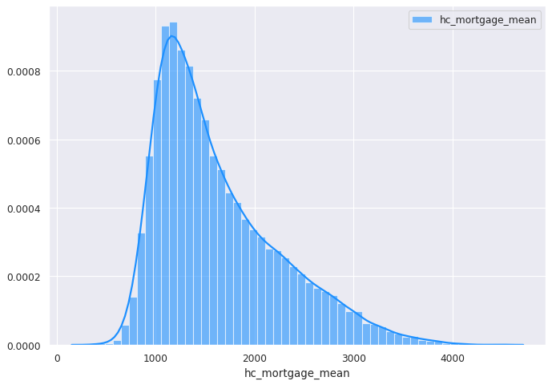

```python
# Plot
kwargs = dict(hist_kws={'alpha':.6}, kde_kws={'linewidth':2})

plt.figure(figsize=(10,7), dpi= 80)
sns.distplot(train_df.hc_mortgage_mean, color="dodgerblue", label="hc_mortgage_mean", **kwargs)
# sns.distplot(x2, color="orange", label="SUV", **kwargs)
# sns.distplot(x3, color="deeppink", label="minivan", **kwargs)
# plt.xlim(50,75)
plt.legend();
```

# Target Variable "hc_mortgage_mean" has a Positive Skew.

```python
from sklearn.linear_model import LinearRegression
```

```python
from sklearn.metrics import mean_squared_error, mean_absolute_error, r2_score, SCORERS
```

```python
lr = LinearRegression()
```

Adj r2 = 1-(1-R2)*(n-1)/(n-p-1)

```python
def adj_rsqrd(df, r2):
        # adjusted r2 using formula adj_r2 = 1 - (1- r2) * (n-1) / (n - k - 1)
    # k = number of predictors = data.shape[1] - 1
    adj_rsqrd = 1 - (1-r2)*(len(df) - 1) / (len(df) - (df.shape[1] - 1) - 1)
    return round(adj_rsqrd, 3)
```

```python
cat_cols_2_drop = ['UID', 'state', 'state_ab', 'city', 'place', 'type', 'primary', 'zip_code', 'area_code', 'lat', 'lng']
```

```python
train_df.drop(cat_cols_2_drop, axis=1, inplace=True)
```

```python
test_df.drop(cat_cols_2_drop, axis=1, inplace=True)
```

```python
train_df.drop(['COUNTYID', 'STATEID'], axis=1, inplace=True)
```

```python
test_y = test_df['hc_mortgage_mean']
```

```python
test_df.drop(['COUNTYID', 'STATEID', 'hc_mortgage_mean'], axis=1, inplace=True)
```

```python
print(train_df.shape, test_df.shape)
```

```
(26585, 65) (11355, 64)
```

```python
train_X = train_df.drop(columns=['hc_mortgage_mean'])
train_y = train_df['hc_mortgage_mean']
```

```python
lr.fit(train_X, train_y)
```

```
LinearRegression(copy_X=True, fit_intercept=True, n_jobs=None, normalize=False)
```

```python
predict_train = lr.predict(train_X)
predict_test = lr.predict(test_df)
```

```python
# model evaluation for testing set

mae = mean_absolute_error(test_y, predict_test)
mse = mean_squared_error(test_y, predict_test)
r2 = r2_score(test_y, predict_test)

print("The model performance for test set")
print("--------------------------------------")
print('MAE is {}'.format(round(mae, 3)))
print('MSE is {}'.format(round(mse, 3)))
print('RMSE is {}'.format(round(mse**(0.5), 3)))
print('R2 score is {}'.format(round(r2, 3)))

print('Adjusted R2 score is {}'.format(adj_rsqrd(test_df, r2)))
```

```
The model performance for test set
--------------------------------------
MAE is 43.675
MSE is 4673.486
RMSE is 68.363
R2 score is 0.988
Adjusted R2 score is 0.988
```

# Regression Model with all dependent numeric variables @ Country level is giving R SQUARED metric of 98.8%. So skipping state level Regression Model

```python
correlated_features = set()
correlation_matrix = train_df.drop('hc_mortgage_mean', axis=1).corr()

for i in range(len(correlation_matrix.columns)):
    for j in range(i):
        if abs(correlation_matrix.iloc[i, j]) > 0.8:
            colname = correlation_matrix.columns[i]
            correlated_features.add(colname)
```

```python
correlated_features
```

```
{'debt_cdf',
 'family_mean',
 'family_median',
 'family_sample_weight',
 'family_samples',
 'family_stdev',
 'female_age_mean',
 'female_age_median',
 'female_age_sample_weight',
 'female_age_samples',
 'female_pop',
 'hc_median',
 'hc_mortgage_samples',
 'hc_sample_weight',
 'hi_median',
 'hi_samples',
 'hi_stdev',
 'home_equity_cdf',
 'hs_degree_female',
 'hs_degree_male',
 'male_age_median',
 'male_age_sample_weight',
 'male_age_samples',
 'male_pop',
 'rent_gt_25',
 'rent_gt_30',
 'rent_gt_35',
 'rent_gt_40',
 'rent_gt_50',
 'rent_median',
 'rent_samples',
 'second_mortgage',
 'universe_samples',
 'used_samples'}
```

```python
corr_list = ['debt_cdf', 'family_mean', 'family_median', 'family_sample_weight', 'family_samples', 'family_stdev', 'female_age_mean', 'female_age_median',
                     'female_age_sample_weight', 'female_age_samples', 'female_pop', 'hc_median', 'hc_mortgage_samples', 'hc_sample_weight', 'hi_median',
                     'hi_samples', 'hi_stdev', 'home_equity_cdf', 'hs_degree_female', 'hs_degree_male', 'male_age_median', 'male_age_sample_weight',
                 'male_age_samples', 'male_pop', 'rent_gt_25', 'rent_gt_30', 'rent_gt_35', 'rent_gt_40', 'rent_gt_50', 'rent_median', 'rent_samples', 'second_mortgage', 'universe_samples', 'used_samples']
```

```python
train_df.drop(corr_list, axis=1, inplace=True)
```

```python
test_df.drop(corr_list, axis=1, inplace=True)
```

```python
print(train_df.shape, test_df.shape)
```

```
(26585, 31) (11355, 30)
```

# Dropped MultiCollinear variables and ran the Regression Model.

```python
train_df.head()
```

|  | ALand | AWater | pop | rent_mean | rent_stdev | rent_sample_weight | rent_gt_10 | rent_gt_15 | rent_gt_20 | hi_mean | hi_sample_weight | hc_mortgage_mean | hc_mortgage_median | hc_mortgage_stdev | hc_mortgage_sample_weight | hc_mean | hc_stdev | hc_samples | home_equity_second_mortgage | home_equity | debt | second_mortgage_cdf | hs_degree | male_age_mean | male_age_stdev | female_age_stdev | pct_own | married | married_snp | … |
| --- | --- | --- | --- | --- | --- | --- | --- | --- | --- | --- | --- | --- | --- | --- | --- | --- | --- | --- | --- | --- | --- | --- | --- | --- | --- | --- | --- | --- | --- | --- |
| 0 | 202183361.0 | 1699120 | 5230 | 769.38638 | 232.63967 | 272.34441 | 0.86761 | 0.79155 | 0.59155 | 63125.28406 | 1290.96240 | 1414.80295 | 1223.0 | 641.22898 | 377.83135 | 570.01530 | 270.11299 | 770.0 | 0.01588 | 0.08919 | 0.52963 | 0.43658 | 0.89288 | 42.48574 | 22.97306 | 22.51276 | 0.79046 | 0.57851 | 0.01882 | … |
| 1 | 1560828.0 | 100363 | 2633 | 804.87924 | 253.46747 | 312.58622 | 0.97410 | 0.93227 | 0.69920 | 41931.92593 | 838.74664 | 864.41390 | 784.0 | 482.27020 | 316.88320 | 351.98293 | 125.40457 | 229.0 | 0.02222 | 0.04274 | 0.60855 | 0.42174 | 0.90487 | 34.84728 | 20.37452 | 23.43353 | 0.52483 | 0.34886 | 0.01426 | … |
| 2 | 69561595.0 | 284193 | 6881 | 742.77365 | 323.39011 | 291.85520 | 0.95238 | 0.88624 | 0.79630 | 84942.68317 | 1155.20980 | 1506.06758 | 1361.0 | 731.89394 | 699.41354 | 556.45986 | 184.42175 | 538.0 | 0.00000 | 0.09512 | 0.73484 | 1.00000 | 0.94288 | 39.38154 | 22.89769 | 23.94119 | 0.85331 | 0.64745 | 0.02830 | … |
| 3 | 1105793.0 | 0 | 2700 | 803.42018 | 297.39258 | 259.30316 | 0.94693 | 0.87151 | 0.69832 | 48733.67116 | 928.32193 | 1175.28642 | 1101.0 | 428.98751 | 261.28471 | 288.04047 | 185.55887 | 392.0 | 0.01086 | 0.01086 | 0.52714 | 0.53057 | 0.91500 | 48.64749 | 23.05968 | 24.32015 | 0.65037 | 0.47257 | 0.02021 | … |
| 4 | 2554403.0 | 0 | 5637 | 938.56493 | 392.44096 | 1005.42886 | 0.99286 | 0.98247 | 0.91688 | 31834.15466 | 1548.67477 | 1192.58759 | 1125.0 | 327.49674 | 76.61052 | 443.68855 | 76.12674 | 124.0 | 0.05426 | 0.05426 | 0.51938 | 0.18332 | 1.00000 | 26.07533 | 11.84399 | 11.10484 | 0.13046 | 0.12356 | 0.00000 | … |

```python
train_X = train_df.drop(columns=['hc_mortgage_mean'])
train_y = train_df['hc_mortgage_mean']
```

```python
lr.fit(train_X, train_y)
```

```
LinearRegression(copy_X=True, fit_intercept=True, n_jobs=None, normalize=False)
```

```python
predict_train = lr.predict(train_X)
predict_test = lr.predict(test_df)
```

```python
# model evaluation for testing set

mae = mean_absolute_error(test_y, predict_test)
mse = mean_squared_error(test_y, predict_test)
r2 = r2_score(test_y, predict_test)

print("The model performance for test set")
print("--------------------------------------")
print('MAE is {}'.format(round(mae, 3)))
print('MSE is {}'.format(round(mse, 3)))
print('RMSE is {}'.format(round(mse**(0.5), 3)))
print('R2 score is {}'.format(round(r2, 3)))

print('Adjusted R2 score is {}'.format(adj_rsqrd(test_df, r2)))
```

```
The model performance for test set
--------------------------------------
MAE is 44.001
MSE is 4787.228
RMSE is 69.19
R2 score is 0.988
Adjusted R2 score is 0.988
```

```python
sorted(SCORERS.keys())
```

```
['accuracy',
 'adjusted_mutual_info_score',
 'adjusted_rand_score',
 'average_precision',
 'balanced_accuracy',
 'completeness_score',
 'explained_variance',
 'f1',
 'f1_macro',
 'f1_micro',
 'f1_samples',
 'f1_weighted',
 'fowlkes_mallows_score',
 'homogeneity_score',
 'jaccard',
 'jaccard_macro',
 'jaccard_micro',
 'jaccard_samples',
 'jaccard_weighted',
 'max_error',
 'mutual_info_score',
 'neg_brier_score',
 'neg_log_loss',
 'neg_mean_absolute_error',
 'neg_mean_gamma_deviance',
 'neg_mean_poisson_deviance',
 'neg_mean_squared_error',
 'neg_mean_squared_log_error',
 'neg_median_absolute_error',
 'neg_root_mean_squared_error',
 'normalized_mutual_info_score',
 'precision',
 'precision_macro',
 'precision_micro',
 'precision_samples',
 'precision_weighted',
 'r2',
 'recall',
 'recall_macro',
 'recall_micro',
 'recall_samples',
 'recall_weighted',
 'roc_auc',
 'roc_auc_ovo',
 'roc_auc_ovo_weighted',
 'roc_auc_ovr',
 'roc_auc_ovr_weighted',
 'v_measure_score']
```

# Let's Check how close our algorithm is predicting, by passing the inputs from our test set and compare them to the target values.

```python
import random
randomlist = []
for i in range(0,100):
    n = random.randint(1,len(test_df))
    randomlist.append(n)
print(randomlist)
```

```
[2763, 8062, 5533, 2284, 4849, 5481, 10274, 10343, 686, 2677, 4962, 3093, 1410, 8188, 3930, 2696, 1042, 5342, 3958, 8889, 4196, 10500, 7046, 8175, 7349, 10539, 4312, 2782, 2806, 9348, 8748, 6082, 254, 5720, 903, 1932, 5393, 7773, 8792, 3777, 5892, 7766, 8093, 6581, 1042, 2601, 2282, 5508, 8812, 2394…
```

```python
pre_out = []
out = []

for i in randomlist:
    data_in = [list(test_df.iloc[i])]
    pre_data_out = lr.predict(data_in)
    data_out = test_y .iloc[i]

    print(i, pre_data_out, data_out)

    pre_out.append(pre_data_out)
    out.append(data_out)
```

```
2763 [1748.34689707] 1776.5331199999998
8062 [2451.61672131] 2476.1307899999997
5533 [1218.61251452] 1209.13441
2284 [1015.62455952] 1060.88337
4849 [1269.2806048] 1207.3707
5481 [1329.21795418] 1377.78559
10274 [914.01565316] 908.08984
10343 [1695.48608339] 1655.10796
686 [2333.76906674] 2374.81665
2677 [1186.37953927] 1274.0943
4962 [2740.73669099] 2793.409
3093 [1837.50845396] 1809.7494199999999
1410 [2466.15879571] 2506.6781300000002
8188 [1477.61976826] 1501.85606
3930 [1181.36397276] 1179.57826
```

[output cut: 85 more lines]

```python
pre_out
```

```
[array([1748.34689707]),
 array([2451.61672131]),
 array([1218.61251452]),
 array([1015.62455952]),
 array([1269.2806048]),
 array([1329.21795418]),
 array([914.01565316]),
 array([1695.48608339]),
 array([2333.76906674]),
 array([1186.37953927]),
 array([2740.73669099]),
 array([1837.50845396]),
 array([2466.15879571]),
 array([1477.61976826]),
 array([1181.36397276]),
 array([3437.11819284]),
 array([1762.61621719]),
 array([921.5946339]),
 array([742.29280314]),
 array([1522.82876646]),
 array([2596.06791077]),
 array([2854.23631024]),
 array([1277.48607328]),
 array([1203.44230014]),
 array([2107.98971739]),
 array([1213.13186559]),
 array([1108.6956764]),
 array([2849.67947956]),
 array([2050.90235889]),
 array([3058.11618195]),
 array([3147.29265012]),
 array([2152.35282592]),
 array([1847.91883109]),
 array([1059.54450024]),
 array([1304.37511704]),
 array([1099.86325238]),
 array([1132.1132647]),
 array([2473.93775495]),
 array([1641.20682962]),
 array([1791.93025147]),
```

[output cut: 45 more lines]

```
 array([1622.14867398]),
 array([2755.91476155]),
 array([1895.33923252]),
 array([1260.1498813]),
 array([1907.80048419]),
 array([1405.36237695]),
 array([1764.4012646]),
 array([1072.61113848]),
 array([1075.42447109]),
 array([1463.70069344]),
 array([1005.68068668]),
 array([3072.65329785]),
 array([1485.51843599]),
 array([1234.9777081]),
 array([1806.28894499])]
```

```python
x = [2,3,5,9,1,0,2,3]

def my_min(sequence):
    """return the minimum element of sequence"""
    low = sequence[0] # need to start with some value
    for i in sequence:
        if i < low:
            low = i
    return low

print(my_min(x))
```

```
0
```

```python
x = [2,3,5,9,1,0,2,3]

def my_maxi(sequence):
    """return the minimum element of sequence"""
    maxi = sequence[0] # need to start with some value
    for i in sequence:
        if i > maxi:
            maxi = i
    return maxi

print(my_maxi(x))
```

```
9
```

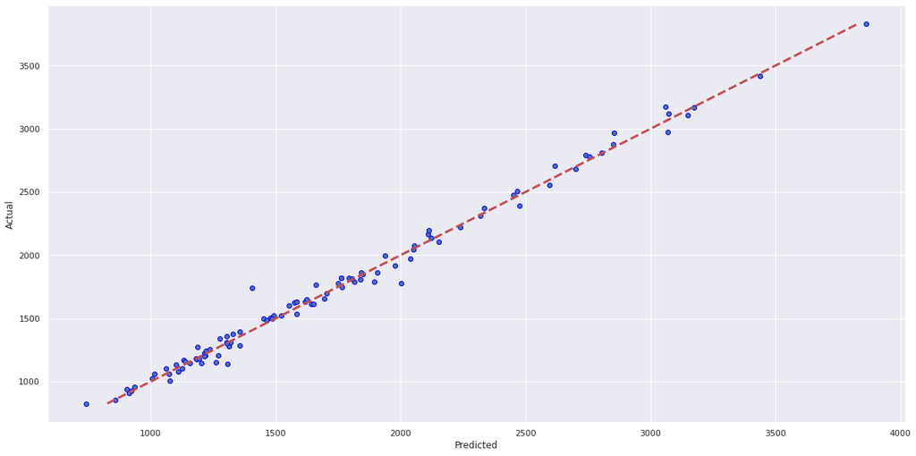

```python
fig, ax = plt.subplots(figsize=(20,10))
ax.scatter(pre_out, out, edgecolors=(0, 0, 1))
ax.plot([my_min(out), my_maxi(out)], [my_min(out), my_maxi(out)], 'r--', lw=3)
ax.set_xlabel('Predicted')
ax.set_ylabel('Actual')
plt.show()
```

```python
# model evaluation for testing set

mae = mean_absolute_error(test_y, predict_test)
mse = mean_squared_error(test_y, predict_test)
r2 = r2_score(test_y, predict_test)

print("The model performance for test set")
print("--------------------------------------")
print('MAE is {}'.format(round(mae, 3)))
print('MSE is {}'.format(round(mse, 3)))
print('RMSE is {}'.format(round(mse**(0.5), 3)))
print('R2 score is {}'.format(round(r2, 3)))

print('Adjusted R2 score is {}'.format(adj_rsqrd(test_df, r2)))
```

```
The model performance for test set
--------------------------------------
MAE is 44.001
MSE is 4787.228
RMSE is 69.19
R2 score is 0.988
Adjusted R2 score is 0.988
```

# We have achieved an adjusted R Squared value of 98.8% which is pretty close to 1, indicating our selected "Independent Variables" are highly correlated to our "Dependent Variable" and our model is able to predict very accurately.